# **Chapter 9: Main Memory**

## **Section 9.1: Background**

#### **1. The Central Role of Memory**

In a modern computer system, **memory (or main memory/RAM)** is a critical component. Think of it as a vast, contiguous array of **storage cells (bytes)**, where each byte has a unique **address**, like house numbers on a very long street.

The CPU's operation is an endless cycle of interacting with this memory:

1. **Fetch Instruction:** The CPU looks at the **Program Counter (PC)** register, which holds the memory address of the next instruction. It goes to that address in memory and fetches the instruction.
2. **Decode & Execute:** The CPU decodes the instruction. This instruction might itself require **fetching data (operands)** from specific memory addresses.
3. **Store Results:** After performing the operation, the CPU may **store the result** back into a specified memory address.

This cycle highlights that **nearly every CPU action involves memory access**.

#### **2. The Memory Unit's Perspective**

From the viewpoint of the **memory hardware unit**, its job is simple:

- **Input:** A stream of memory addresses.
- **Action:** For each address, either **read** the data stored there or **write** new data to it.
- **Crucial Point:** The memory unit is "dumb." It **does not know or care** *how* an address was generated (by the program counter, by calculating an offset, etc.) or *what* the data at that address represents (an instruction, an integer, text, etc.). Its sole concern is the address number itself.

Therefore, when studying memory management from the OS perspective, we focus on the **sequence of memory addresses** produced by a running program, not on their semantic meaning.

#### **3. Key Issues in Memory Management**

This section will explore several foundational concepts needed to understand how an operating system manages this crucial resource:

- **Basic Hardware:** What hardware mechanisms (like **base and limit registers**) are needed to support memory management and protection.
- **Address Binding:** Programs are written using **symbolic names** (like variable names). These must eventually be translated into specific physical memory addresses. The process and timing of this **binding** is a key concept.
- **Logical vs. Physical Addresses:**
  - **Logical Address (Virtual Address):** An address generated by the CPU during program execution. It's the program's *view* of memory.
  - **Physical Address:** The actual address used by the memory hardware unit. The **Memory Management Unit (MMU)** hardware dynamically translates logical addresses into physical addresses.
- **Dynamic Linking and Shared Libraries:** How multiple programs can share common library code in memory, reducing duplication and saving memory space. This involves delaying the linking of some code until the program is actually running.

**Next Steps:** We will first look at the hardware support required to implement these concepts effectively. (As per your book's structure, this leads into discussions of hardware, address binding, and the logical/physical distinction).

### **Section 9.1.1: Basic Hardware**

#### **1. Direct CPU-Accessible Storage**

The CPU can directly interact with only two types of storage:

1. **CPU Registers:** Built into each processor core. Access is extremely fast (typically within one CPU clock cycle).
2. **Main Memory (RAM):** Accessed via the system bus. Access is much slower, taking many CPU clock cycles.

**Key Implication:** All **instructions and data** that the CPU is actively working on **must be copied into main memory** (or registers). Data on disk must be moved to RAM before the CPU can use it. There are no CPU instructions that operate directly on disk addresses.

#### **2. The Speed Problem and Caching**

The massive speed difference between register access and RAM access creates a performance bottleneck. If the CPU had to wait (**stall**) for every memory access, system performance would be terrible.

**The Solution:** **Caches**. Fast, small memory located between the CPU and main RAM (often on the CPU chip itself). The cache automatically holds frequently used data from main memory, dramatically speeding up access. Cache management is handled **transparently by hardware**, not the OS.

*(Note: As mentioned in your computer architecture course, this is the memory hierarchy. Multithreaded cores can also switch to another thread during a stall to utilize idle cycles.)*

#### **3. The Protection Problem**

We must prevent user processes from interfering with each other or with the operating system itself. This **memory protection** must be enforced by **hardware** because software (OS) checking every memory access would be too slow.

#### **4. Hardware Solution: Base and Limit Registers**

A classic and fundamental hardware mechanism for memory protection uses two special CPU registers:

- **Base Register:** Holds the **starting physical address** of a process's memory region.
- **Limit Register:** Holds the **size (length)** of that memory region.

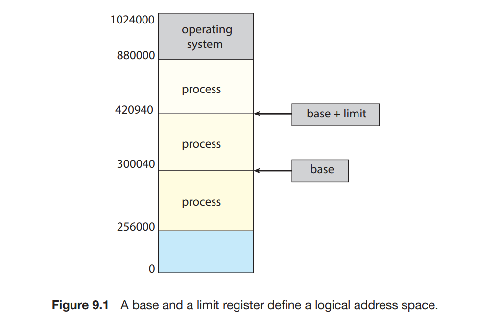

##### **How Protection Works (The MMU's Role):**

The **Memory Management Unit (MMU)** is the hardware component that performs this check. Here's the sequence for every memory address generated by a user process:

1. The CPU generates a **logical address** (e.g., from 0 to limit-1).
2. The MMU **adds this logical address to the value in the base register** to produce a **physical address**.
3. **Crucially, before allowing the access, the MMU checks if the logical address is less than the value in the limit register.**
4. If the address is **≥ the limit**, it is **illegal**. The MMU triggers a hardware trap (an interrupt) to the OS, which typically terminates the offending process.

**Go to Figure 9.2** in your book. This flowchart visualizes the hardware's address validation process, showing the comparison and the trap to the OS on violation.

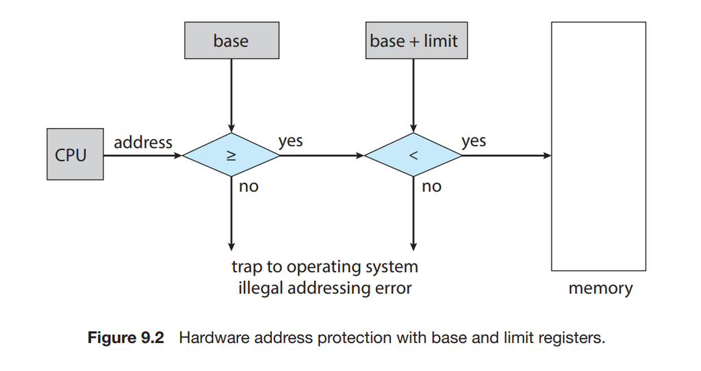

##### **Example:**

If a process has `Base = 300040` and `Limit = 120900`:

- Its **legal physical address range** is from `300040` to `(300040 + 120900 - 1) = 420939`.
- A process request for logical address `0` becomes physical address `300040`. ✅
- A process request for logical address `120899` becomes physical address `420939`. ✅
- A process request for logical address `120900` (equal to limit) is **invalid** and causes a trap. ❌

#### **5. Operating System Privilege**

The base and limit registers are **privileged resources**.

- They can only be loaded by instructions that execute in **kernel mode** (a higher privilege level).
- Only the **operating system** runs in kernel mode.
- This prevents a user process from changing its own memory bounds to access unauthorized areas.

The OS itself, running in kernel mode, has **unrestricted access** to all of memory. This is necessary for it to perform its duties: loading programs, handling system calls, performing I/O between user memory and devices, and switching between processes (**context switches**), which involves saving/restoring process state (including registers) to/from memory.

### **Section 9.1.2: Address Binding**

#### **1. The Journey of a Program to Memory**

A program starts its life as an **executable file on disk**. To run, it must be loaded into **main memory** and become a **process**. The process then executes, fetching instructions and data from memory, and finally terminates, freeing its memory.

A key point: the process can be placed **anywhere** in physical memory. Its starting address in memory does *not* have to be zero, even though the computer's physical address numbering starts at 0. The OS decides where to place it.

#### **2. Address Representations and Binding Steps**

**Address Binding** is the process of translating the **symbolic addresses** in a program (like variable names) into actual, numeric **physical memory addresses**. This happens in stages. **Go to Figure 9.3** in your book, which illustrates this multistep pipeline.

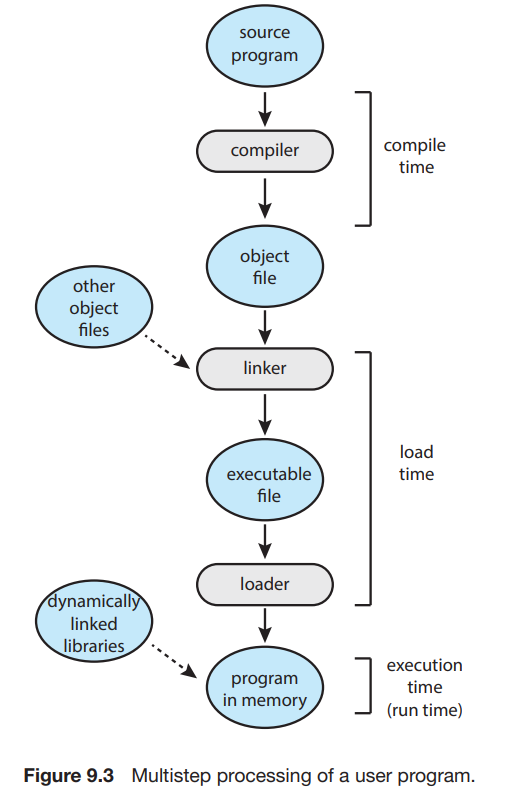

Here are the stages and the form of addresses at each stage:

1. **Source Program:** Uses **symbolic addresses** (e.g., `count`, `main`, `loop`).
2. **Compilation:** The compiler translates symbolic addresses into **relocatable addresses** (also called logical addresses). These are offsets relative to the start of the module (e.g., "byte 14 within this function" or "the variable located 200 bytes from the start of the data section").
3. **Linking/Loading:** The **linker** (which combines multiple object files and libraries) and the **loader** (which places the program into memory) perform the final mapping to **absolute physical addresses** (e.g., physical memory byte `74014`).

**Each step is a mapping from one address space to another.**

#### **3. Timing of Address Binding (A Critical Concept)**

The final binding to a physical address can occur at different times, each with implications for flexibility and hardware requirements.

##### **Option 1: Binding at Compile Time**

- **How it works:** The compiler knows **in advance** the exact memory location (say, address `R`) where the process will be loaded. It generates **absolute code** containing direct physical addresses.
- **Implication:** If the starting location `R` ever needs to change (e.g., the OS evolves, or you want to run multiple copies), you **must recompile the entire program**.
- **Use Case:** Rare for general-purpose OSes. Might be used in simple, dedicated embedded systems with fixed memory layouts.

##### **Option 2: Binding at Load Time**

- **How it works:** The compiler produces **relocatable code** (code that uses offsets). The final physical address is calculated when the program is **loaded into memory**. The **loader** adds the actual starting physical address to every relocatable address.
- **Implication:** If you need to move the program, you just need to **reload** it; no recompilation is necessary. However, once loaded, the process **cannot be moved** in memory during execution.
- **Use Case:** Used in some older or simpler systems. Provides more flexibility than compile-time binding.

##### **Option 3: Binding at Execution Time (Run Time)**

- **How it works:** Binding is delayed until the **moment the instruction is executed**. The process can be moved **during execution** from one memory region to another. This requires specialized **hardware support**—specifically, a **Memory Management Unit (MMU)** with registers like the **base register** we just discussed.
- **How it works with hardware:** The CPU generates **logical addresses** (e.g., from 0 to N). The MMU's base register, which holds the current physical starting address of the process, is added to every logical address to produce the physical address **on the fly**. If the OS moves the process, it simply updates the base register.
- **Implication:** Maximum flexibility. Enables advanced techniques like **virtual memory**, where processes can be swapped to disk and back into different memory locations.
- **Use Case:** This is the method used by **almost all modern general-purpose operating systems** (Windows, Linux, macOS).

#### **Summary**

The choice of binding time represents a trade-off:

- **Early Binding (Compile/Load Time):** Simpler, less hardware needed, but inflexible.
- **Late Binding (Execution Time):** Requires complex hardware (MMU) but provides powerful flexibility for the OS to manage memory dynamically, which is essential for multitasking and efficient memory utilization.

### **Section 9.1.3: Logical Versus Physical Address Space**

#### **1. Defining the Two Key Address Types**

It is crucial to distinguish between the two perspectives on memory addresses in a system:

- **Logical Address (Virtual Address):** An address **generated by the CPU** during the execution of a program. This is the address the program itself "sees" and works with. It is *process-centric*.
- **Physical Address:** An address that is **actually placed on the memory bus** and used by the **memory hardware unit** to read from or write to a specific cell in RAM. This is the *hardware-centric* view.

**Go to Figure 9.4** in your book. This simple diagram shows the data flow: the CPU outputs a **logical address**, the **MMU** transforms it, and the **memory** receives a **physical address**.

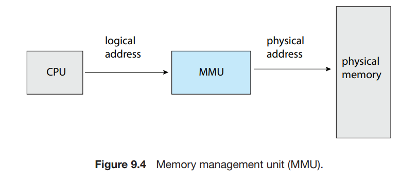

#### **2. The Relationship Depends on Binding Time**

The relationship between logical and physical addresses is determined by when address binding occurs:

- **Compile-time or Load-time Binding:** Here, the logical address generated by the CPU is **identical** to the physical address used by memory. There is a **one-to-one, fixed mapping** decided early on.
- **Execution-time (Run-time) Binding:** This is where the key distinction arises. The logical address (now specifically called a **virtual address**) is **different** from the physical address. The mapping is dynamic and can change while the program runs.

**Therefore:**

- The collection of all logical addresses a program can generate is its **logical address space** (or **virtual address space**).
- The collection of all actual locations in physical memory that these logical addresses map to is its **physical address space**.
- With run-time binding, the **logical and physical address spaces are separate but connected** through dynamic mapping.

#### **3. The Hardware Enabler: The Memory Management Unit (MMU)**

The runtime translation from logical to physical address is performed by a dedicated hardware component called the **Memory Management Unit (MMU)**.

- The MMU sits logically between the CPU and the main memory.
- **Every** memory reference from the CPU (instruction fetch, data load/store) is intercepted by the MMU and translated.

#### **4. A Fundamental MMU Scheme: Dynamic Relocation**

The simplest MMU scheme is a direct generalization of the base-register protection method, now focused on translation. In this context, the base register is often called a **relocation register**.

**How Dynamic Relocation Works:**

1. The CPU, while executing a user process, generates a **logical address** (e.g., `346`). The process believes it is accessing its own "local" address `346`.
2. This logical address is sent to the **MMU**.
3. The MMU **adds the value in the relocation register (R)** to the logical address.
4. The result is the **physical address** (e.g., `R + 346`) that is sent to the memory bus.

**Go to Figure 9.5** in your book. This figure perfectly illustrates the process: the CPU outputs logical address `346`, the relocation register holds value `14000`, the MMU adds them, and physical address `14346` is sent to memory.

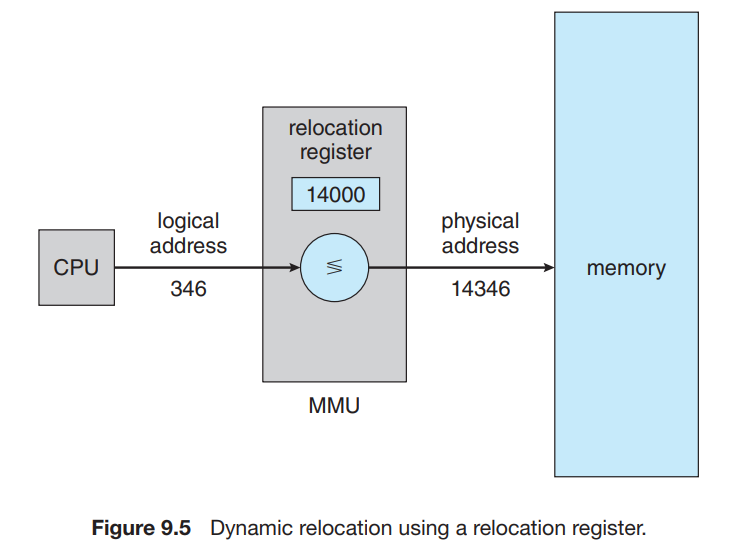

**Example:** If the relocation register (base) is set to `14000`:

- Logical address `0` → Physical address `14000`
- Logical address `346` → Physical address `14346`
- Logical address `MAX` (the process limit) → Physical address `14000 + MAX`

#### **5. The Illusion Created for the User Program**

A powerful **abstraction** is created:

- The **user program operates solely in its logical address space** (0 to max). It creates pointers, compares addresses, and performs calculations all within this logical space, completely unaware of where it physically resides in RAM.
- The **operating system** (with help from the MMU) manages the physical address space. It decides the value of the relocation register (R) for each process. It can change this value to move a process in memory **without the process ever knowing**.
- The actual, final physical location of any memory reference **is not determined until the very moment the CPU generates that reference and the MMU translates it**.

#### **6. Central Concept of Modern Memory Management**

The separation of the **logical address space** (belonging to the process) from the **physical address space** (belonging to the hardware) is the **foundational idea** behind all advanced memory management techniques. This separation is what allows for:

- **Process Isolation:** Each process has its own private, contiguous address space starting at 0.
- **Dynamic Relocation:** Processes can be moved in physical memory during execution.
- **Memory Protection:** The limit register check (from 9.1.1) ensures a process cannot generate logical addresses outside its allocated range.
- **The eventual implementation of Virtual Memory:** Where the logical address space can be much larger than the physical address space.

### **Section 9.1.4: Dynamic Loading**

#### **1. The Problem and The Concept**

Until now, our discussion assumed the **entire program** (all code and data) must be in physical memory for execution. This limits a process's size to available physical RAM.

**Dynamic Loading** is a technique to improve memory utilization. The core idea: **Do not load a subroutine/routine into memory until it is actually called (invoked).**

#### **2. How Dynamic Loading Works**

1. The **main program** is loaded into memory and begins execution. All other routines (subroutines, functions, modules) remain on disk in a **relocatable load format** (ready to be loaded and have addresses adjusted).
2. When the main program (or a loaded routine) needs to call another routine, it first checks a **routine table** to see if that routine is already in memory.
3. If the routine is **not loaded**, the program calls the **relocatable linking loader**.
   - The loader finds the routine on disk.
   - It loads the routine into an available block of memory.
   - It **updates the program's address tables** to reflect the new location of this routine.
4. Control is then transferred to the newly loaded routine.

#### **3. Advantages and Responsibilities**

- **Advantage:** Memory is used only for code that is actually needed. This is extremely useful for large programs with significant portions dedicated to **infrequent operations** (e.g., error handling routines, special features). The total program size on disk can be large, but its **memory footprint** can be much smaller.
- **Responsibility:** Dynamic loading primarily **does not require special OS hardware support**. It is a **programming design** technique. The programmer (or compiler tools) must structure the program to facilitate this loading-on-call.
- **OS Role:** The operating system may provide **library routines** to help programmers implement dynamic loading more easily, but the core mechanism is managed by the program itself.

### **Section 9.1.5: Dynamic Linking and Shared Libraries**

#### **1. Linking vs. Loading**

It's vital to distinguish this from dynamic loading:

- **Linking:** The process of **resolving references** between different code modules (e.g., your program calling `printf()`). It connects your code to library code.
- **Loading:** The process of **copying** code/data from disk into memory.

**Static Linking** (the traditional method) combines all library code your program needs directly into the program's executable file *at compile/link time*. This creates large executables and wastes memory if multiple running programs include the same library code.

#### **2. The Concept of Dynamic Linking**

**Dynamic Linking** postpones the linking step until **execution time** (run time). The executable file contains only **references** to external library routines, not the library code itself.

These dynamically linked libraries are called **Dynamically Linked Libraries (DLLs)** in Windows or **Shared Libraries** (e.g., `.so` files) in Unix/Linux.

#### **3. How Dynamic Linking Works**

1. When a dynamically linked program is loaded, the OS **loader** runs.
2. The loader sees the program's references to DLLs. It **locates the required libraries** on disk.
3. The loader **checks if the library is already loaded in memory** (perhaps by another running program). If not, it loads the library.
4. The loader then **patches (adjusts) the program's address tables** so that calls to library functions (like `printf`) point to the correct memory address where the library is now located.

#### **4. Key Advantages of Dynamic Linking & Shared Libraries**

1. **Reduced Executable File Size:** The executable file on disk is smaller because it doesn't contain the library code.
2. **Efficient Memory Use (Sharing):** This is the major advantage. **Only one physical copy of a library routine needs to be in RAM**, even if it is used by **dozens of different processes**. All processes map their logical address for `printf` to the **same physical memory location**. This saves tremendous amounts of memory. **(We will see exactly *how* this sharing is implemented when we discuss Paging in Section 9.3.4).**
3. **Easier Library Updates:** A library (e.g., for bug fixes or performance improvements) can be replaced on disk. **All programs that use it will automatically start using the new version** the next time they run, without needing to be recompiled or relinked.
4. **Version Management:** To prevent new, incompatible library versions from breaking old programs, **version information** is embedded. Multiple versions of the same library can coexist in memory. A program is linked to a specific major version number and will use that version, protecting system stability.

#### **5. Essential Operating System Role**

Unlike dynamic loading, dynamic linking **absolutely requires active help from the operating system**. Why?

- **Memory Protection:** In a protected memory system, one process cannot normally access another process's memory. Only the OS (in kernel mode) can set up the necessary mappings to allow **multiple processes to access the same physical memory pages** (the shared library code).
- **Coordination & Security:** The OS must manage the shared library's load address, enforce access permissions (typically read-only for code), and ensure security.

**The detailed mechanism of how multiple processes share the same physical pages for code will be covered in Section 9.3.4 (Paging).**

## **Section 9.2: Contiguous Memory Allocation**

#### **1. The Memory Allocation Problem**

The OS must share the finite resource of **physical main memory (RAM)** between:

- The **Operating System** kernel itself.
- Multiple **User Processes**.

The goal is to allocate memory to processes **efficiently** (minimizing waste) and **fairly**. This section introduces a foundational model: **Contiguous Memory Allocation**.

#### **2. Memory Layout: The Two Partitions**

Physical memory is conceptually split into two major regions (partitions):

1. **Operating System Partition:** Holds the kernel code, data, and kernel structures.
2. **User Processes Partition:** The remaining memory where user applications are loaded.

**Placement of the OS:** The OS can be placed in **low memory** (addresses starting at 0) or **high memory** (addresses at the top of the physical address space). The choice depends on factors like where the hardware's **interrupt vector** (a table of addresses for handling hardware events) is located. **Most modern OSes (like Linux and Windows) place the OS in high memory.** Our discussion will assume this high-memory OS layout.

#### **3. What is "Contiguous Allocation"?**

In the contiguous allocation model:

- Each process is allocated **one single, continuous block** of memory addresses.
- The block for one process is placed next to (contiguous with) the block for the next process in memory.
- This creates a sequence of processes in memory, like cars parked bumper-to-bumper.

Before we can manage these allocations, we must ensure **memory protection** between these adjacent processes.

### **Section 9.2.1: Memory Protection**

#### **1. The Combined Hardware Mechanism**

Protection is achieved by using **both hardware registers** we previously discussed, now working together as a pair within the MMU:

- **Relocation Register (Base Register):** Holds the **starting physical address** of the process.
- **Limit Register:** Holds the **size (length)** of the process's logical address space.

**These two registers define the process's allocated memory block completely and enforce protection.**

#### **2. How Translation and Protection Work (Step-by-Step)**

For **every** memory address generated by the CPU (logical address):

1. The MMU **compares the logical address against the limit register**.
   - If `logical address >= limit`, the address is **illegal**. The MMU triggers a trap (fault) to the OS.
2. If the address is legal (`logical address < limit`), the MMU **adds the logical address to the value in the relocation register** to produce the **physical address**.
3. This physical address is sent to the memory bus for the actual read/write operation.

**Go to Figure 9.6** in your book. This figure illustrates this combined check-and-translate operation within the MMU hardware.

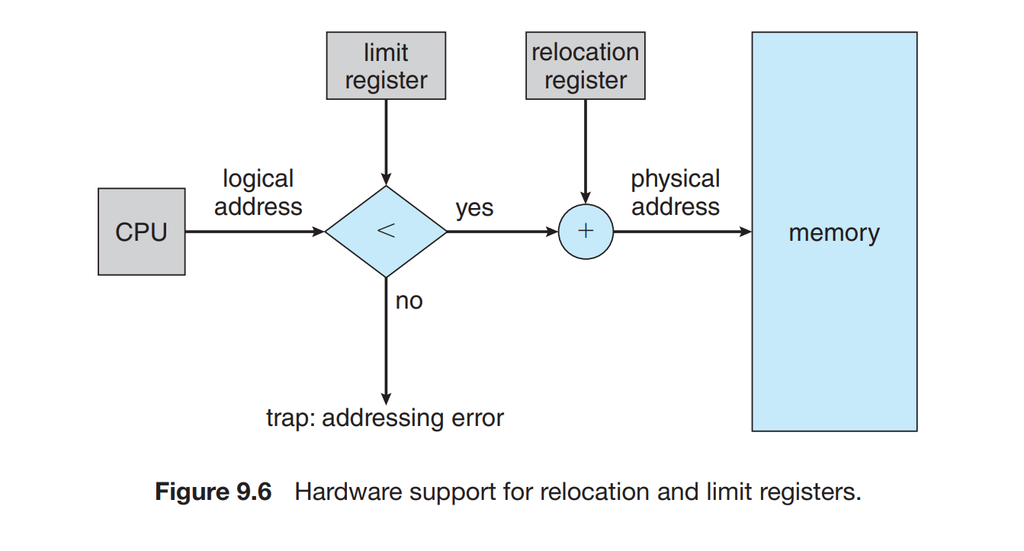

**Example:** Relocation = `100040`, Limit = `74600`.

- Process's **logical address space** is from 0 to 74599.
- Process's **physical address space** is from 100040 to (100040 + 74599) = 174639.
- A CPU reference to logical address `0` → passes limit check (<74600) → becomes physical address `100040`.
- A CPU reference to logical address `74600` → fails limit check (>=74600) → triggers a **protection fault**.

#### **3. Role During Context Switches**

When the OS **switches the CPU from one process to another** (a context switch), the **dispatcher** (part of the OS scheduler) must:

1. Save the old process's relocation and limit register values (part of its saved state).
2. **Load the new process's correct relocation and limit values** into the physical MMU registers. This ensures each process only has access to its own specific, contiguous block of memory.

#### **4. Dynamic Flexibility for the Operating System**

This scheme also benefits the OS itself. The **OS's own memory size can change dynamically**.

- **Example:** A **device driver** for a printer doesn't need to be in memory if no printer is connected. It can be kept on disk.
- When the printer is plugged in, the OS can **load the driver code** into a free area of the OS partition in high memory.
- If the printer is disconnected, the OS can **remove (unload) the driver**, freeing that memory for other OS needs (like caches or another driver).
- The user processes are unaffected because their relocation/limit registers still define their own separate, protected region in lower memory.

**In summary, the relocation+limit register pair provides the essential hardware foundation for both dynamic address translation and strict memory protection in a contiguous allocation model.** The next step is to explore the algorithms the OS uses to *choose where* to place these contiguous blocks in the free memory space.

### **Section 9.2.2: Memory Allocation**

#### **1. The Variable-Partition Scheme**

We now focus on how the OS decides *where* to place a new process in the user memory partition. The model is **Contiguous Allocation with Variable-Sized Partitions**.

- Each process gets **one contiguous block** of memory.
- Block sizes **vary** according to the process's actual needs.
- The OS maintains a data structure (a **table** or **list**) tracking all regions of memory: which are **allocated** (to processes) and which are **free** (available holes).

#### **2. The Lifecycle of Memory: Holes and Fragmentation**

**Go to Figure 9.7** in your book. This figure perfectly illustrates the dynamic nature of memory under this scheme.

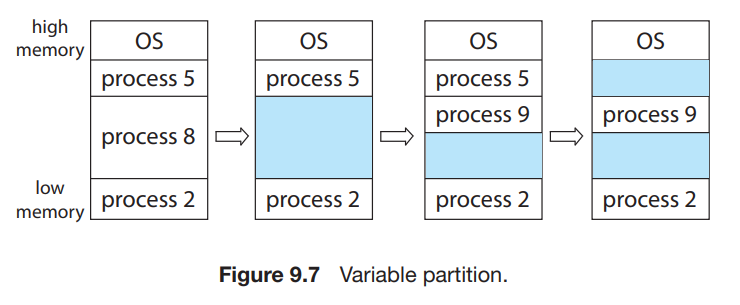

- **Initial State:** Memory is full of processes (e.g., P5, P8, P2).
- **Process Termination:** When a process finishes (e.g., P8), it releases its memory, creating a **hole**—a contiguous block of free memory.
- **New Process Arrival:** A new process (e.g., P9) arrives. The OS must find a **hole large enough** to fit P9. If found, P9 is loaded there.
- **More Terminations:** Another process (P5) terminates, creating a **second hole**. Now free memory is **fragmented** into two non-contiguous holes.

This cycle of allocation and deallocation leads to a memory landscape scattered with **holes of various sizes**.

#### **3. Handling Insufficient Memory**

What if a new process arrives and **no single hole is large enough** to hold it?

1. **Option 1: Reject the Process.** The OS can refuse to admit the process, often with an "out of memory" error.
2. **Option 2: Use a Wait Queue.** The process is placed in a **suspended queue**. Whenever a process terminates and frees memory, the OS **scans this queue** to see if any waiting process can now fit into the newly created (and possibly merged) hole.

#### **4. The Core Allocation/Deallocation Procedures**

The OS constantly performs these operations:

**A. Allocating Memory for a New Process:**

1. **Search:** The OS searches its list of free holes for one that is **large enough** to hold the process.
2. **Split:** If the chosen hole is **larger** than needed, it is **split** into two parts:
   - One part (of the exact size required) is **allocated** to the new process.
   - The remaining part becomes a **new, smaller hole** returned to the free list.

**B. Deallocating Memory on Process Termination:**

1. **Release:** The process's memory block is marked as **free**, becoming a new hole.
2. **Merge (Coalesce):** The OS **immediately checks if this new hole is adjacent** to any other existing hole(s). If it is, it **merges (coalesces)** them into a single, larger hole. This is critical to combat **external fragmentation** (discussed next).

#### **5. The Dynamic Storage-Allocation Problem**

This is a classic problem: Given a list of free holes and a request for `n` bytes, which hole should we choose?

Three common **placement algorithms** are used:

##### **Algorithm 1: First-Fit**

- **Rule:** Allocate the **first** hole in the list that is big enough.
- **Implementation:** Search can start at the beginning of the list each time, or from where the last first-fit search ended (a **next-fit** variant).
- **Advantage:** **Fast**. The search stops at the first acceptable hole.
- **Disadvantage:** Can lead to uneven fragmentation over time.

##### **Algorithm 2: Best-Fit**

- **Rule:** Allocate the **smallest** hole that is big enough to satisfy the request.
- **Implementation:** Must **search the entire free list** (unless it's pre-sorted by size).
- **Advantage:** Tries to **minimize wasted space** in the chosen hole, leaving the largest possible leftover blocks intact.
- **Disadvantage:** **Slower** (requires full scan). Ironically, it often creates **many tiny, useless leftover holes** ("external fragmentation").

##### **Algorithm 3: Worst-Fit**

- **Rule:** Allocate the **largest** available hole.
- **Implementation:** Must also **search the entire free list** (unless sorted).
- **Rationale:** The leftover hole after allocation will be as large as possible, hopefully still useful for future requests.
- **Disadvantage:** **Simulations show it generally performs the worst** in terms of memory utilization and speed. It tends to quickly break down large free blocks.

#### **6. Performance Comparison**

- **Speed:** **First-Fit** is generally the fastest.
- **Storage Utilization (Minimizing Fragmentation):**
  - Both **First-Fit** and **Best-Fit** are better than **Worst-Fit**.
  - There is **no clear winner** between First-Fit and Best-Fit in pure utilization; it depends on the exact workload. However, Best-Fit's tendency to create tiny fragments is a significant practical drawback.
- **Practical Choice:** Due to its speed and acceptable utilization, **First-Fit (or Next-Fit)** is often the algorithm of choice in simple systems.

**The fundamental flaw of all these contiguous allocation schemes, regardless of the placement algorithm, is *external fragmentation*—the existence of many small, non-contiguous free holes scattered throughout memory, which together may have enough total free space for a process, but no single hole is large enough. This is the major drawback that motivates more advanced memory management schemes like Paging.**

### **Section 9.2.3: Fragmentation**

#### **1. The Core Problem: External Fragmentation**

All variable-partition contiguous allocation schemes (First-Fit, Best-Fit, Worst-Fit) suffer from **External Fragmentation**.

- **Definition:** External fragmentation occurs when the **total free memory is sufficient** to satisfy a request, but it is **not available in a single, contiguous block**. Instead, free memory is scattered as many small, separate **holes** between allocated processes.
- **Severity:** This can be crippling. In the worst case, every two processes could have a small, unusable hole between them. If all these holes were merged, they could form a block large enough to run another process.
- **The 50-Percent Rule:** Statistical analysis shows a grim pattern. For `N` allocated blocks using First-Fit, approximately **an additional 0.5N blocks worth of memory will be lost to fragmentation**. This implies **up to one-third of total memory may be unusable** at any time, purely due to fragmentation overhead.

**Which algorithm affects fragmentation?** The choice of First-Fit vs. Best-Fit influences the *pattern* and *size* of fragments, but **neither eliminates external fragmentation**. Best-Fit is particularly notorious for creating many **tiny, useless holes**.

#### **2. A Different Problem: Internal Fragmentation**

Fragmentation isn't only about holes *between* processes. **Internal Fragmentation** is waste *inside* an allocated memory block.

- **Scenario:** Imagine a system with a hole of exactly 18,464 bytes. A process requests 18,462 bytes. A perfect fit leaves a **2-byte hole**.
- **The Overhead Issue:** The metadata needed to track this new 2-byte hole (pointers, size info) will likely consume **more than 2 bytes**, making it nonsensical to manage.
- **The Common Solution:** To avoid this, systems often **allocate memory in fixed-size units (blocks)**. If a process requests memory, it gets rounded up to the next block size.
- **Definition:** The **difference** between the memory actually allocated to the process and the memory it requested is **internal fragmentation**—unused memory *inside* its allocated partition. This space is allocated to the process but cannot be used by it.

**Key Difference:** External Fragmentation = Unallocated free space between processes. Internal Fragmentation = Wasted space inside an allocated block.

#### **3. Solution 1: Compaction**

One direct attack on **external fragmentation** is **Compaction**.

- **Goal:** To **shuffle all occupied memory areas** (processes) together, collecting **all free holes into one large, contiguous free block**.
- **Requirement:** Compaction is **only possible if relocation is dynamic (at execution time)**. The OS must be able to move a process in physical memory and simply update its **base/relocation register** so the process continues running unaware. Static (compile or load-time) binding makes compaction impossible.
- **The Algorithm:** The simplest method is to move **all processes down** (or up) to one end of memory, sliding them past any holes.
- **The Major Drawback: Cost.** Compaction is **extremely expensive** in terms of CPU time. Copying large blocks of memory is slow, and the system is typically frozen during the operation. It is often a last-resort or infrequent operation.

#### **4. Solution 2: Noncontiguous Allocation (Paging)**

A more fundamental and elegant solution to external fragmentation is to **abandon the requirement that a process's address space be contiguous in physical memory**.

- **Core Idea:** Allow a process to be allocated physical memory in **multiple, small, fixed-size blocks** that can be placed in **any available physical location**, scattered throughout memory.
- **The Technique:** This is the essence of **Paging**, the dominant memory-management technique in modern operating systems.
- **How it Solves Fragmentation:** Since memory is divided into small, fixed-size chunks (called **frames**), any free frame anywhere can be used for *part* of a process. External fragmentation in the classic sense is eliminated (though a related, minor form may exist). The small, fixed allocation unit also makes internal fragmentation more predictable and manageable.

#### **5. The Bigger Picture**

Fragmentation is a **universal systems problem** that appears whenever a resource (memory, disk space) must be managed in variable-sized blocks. The trade-offs between external and internal fragmentation, and the costs of compaction, lead directly to the design of more sophisticated systems like **paging** (Chapter 9.3) and **segmentation**, which you will study next. The same concepts reappear in **file-system storage management** (Chapters 11-15).

## **Section 9.3: Paging**

#### **1. Introduction: The Noncontiguous Solution**

Previous memory management schemes required a **contiguous physical address space** for each process, leading to **external fragmentation** and the need for costly **compaction**.

**Paging** is a fundamental scheme that solves this by allowing a process's physical address space to be **noncontiguous**. This avoids external fragmentation and is the dominant memory management technique in modern OSes (servers, desktops, mobile devices). It requires **cooperation between the OS software and the computer hardware (MMU)**.

### **Section 9.3.1: Basic Method**

#### **1. The Core Idea: Pages and Frames**

Paging involves dividing memory into fixed-sized units:

- **Frame:** A fixed-size block of **physical memory**.
- **Page:** A block of **logical memory** of the **exact same size** as a frame.

**How it works:**

1. When a process is executed, its **pages** (from the executable file on disk) are loaded into **any available memory frames**, which do *not* need to be contiguous.
2. The **backing store** (disk) is also organized into blocks the same size as frames (or multiples thereof).
3. **Key Consequence:** This **completely separates the logical and physical address spaces**. A process can use a massive 64-bit logical address space (e.g., 2^64 bytes) even if the machine has far less physical RAM. The OS and MMU manage the mapping illusion.

#### **2. Address Translation: Splitting the Logical Address**

Every logical address generated by the CPU is treated as a single number. The hardware divides it into two parts:

1. **Page Number (p):** Identifies *which page* within the process's logical address space this address belongs to.
2. **Page Offset (d):** Identifies the specific byte *within that page*.

```
Logical Address: | Page Number (p) | Page Offset (d) |
```

**Go to Figure 9.8** in your book. This diagram shows the hardware (MMU) taking the logical address, splitting it, using `p` to index a page table, and combining the resulting frame number with `d` to get the physical address.

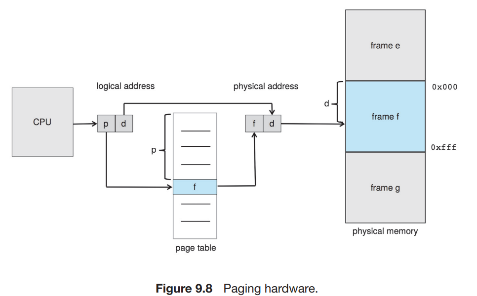

#### **3. The Page Table: The Mapping Directory**

- The **Page Table** is the data structure that performs the mapping. **Each process has its own page table.**
- It is indexed by the **page number (p)**.
- Each entry in the page table contains the **base address (frame number)** where that particular page is currently located in physical memory.

#### **4. The Paging Model Visualization**

**Go to Figure 9.9** in your book. This is a crucial visualization:

- **Logical Memory (Left):** Shows the process's view—pages 0, 1, 2, 3 in order.
- **Page Table (Center):** Shows the mapping. For example, Logical Page 1 → Physical Frame 4.
- **Physical Memory (Right):** Shows the reality—the pages are scattered in noncontiguous frames (e.g., Page 0 in Frame 1, Page 1 in Frame 4, etc.). The offset (`d`) within each page/frame remains the same.

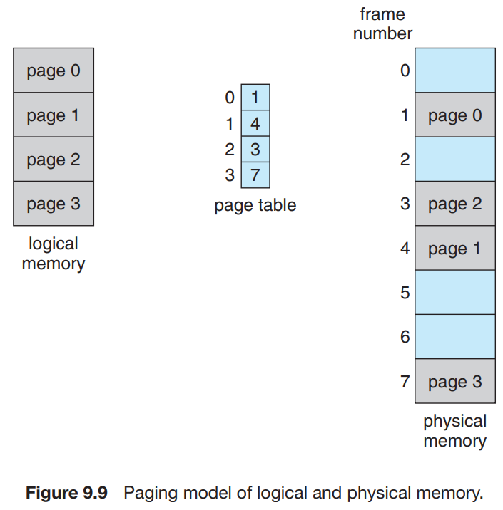

#### **5. Step-by-Step Translation by the MMU**

For each logical address, the MMU performs these steps automatically:

1. **Extract `p` and `d`:** The hardware divides the logical address into the page number (`p`) and page offset (`d`).
2. **Consult Page Table:** Use `p` as an **index** into the process's page table to look up the corresponding **physical frame number (`f`)**.
3. **Form Physical Address:** Replace the logical page number `p` with the physical frame number `f`. The **offset `d` remains unchanged**. The physical address is the concatenation: `f` + `d`.

```
Physical Address: | Frame Number (f) | Page Offset (d) |
```

#### **6. Page Size and Efficient Address Splitting**

- Page size is a **hardware design choice**, always a **power of 2** (e.g., 4 KB, 2 MB, 1 GB). Using a power of 2 makes the address split extremely efficient in hardware.
- **How the split works:**
  - Let the **logical address space size** be 2^`m` bytes (so an address is `m` bits long).
  - Let the **page size** be 2^`n` bytes.
  - Then, the **page number (`p`)** uses the **high-order `m - n` bits** of the logical address.
  - The **page offset (`d`)** uses the **low-order `n` bits**.

**Example:** If logical addresses are 32 bits (`m=32`) and page size is 4KB (2^12 bytes, `n=12`), then:

- The **high 20 bits** (`32-12`) are the page number `p` (allowing up to 2^20 pages).
- The **low 12 bits** are the page offset `d` (addressing each of the 4096 bytes in a page).

This split is performed by simple bit masking and shifting in hardware, making translation very fast.

#### **Concrete Paging Example**

**Go to Figure 9.10** in your book. Let's walk through this small-scale example to solidify the concept.

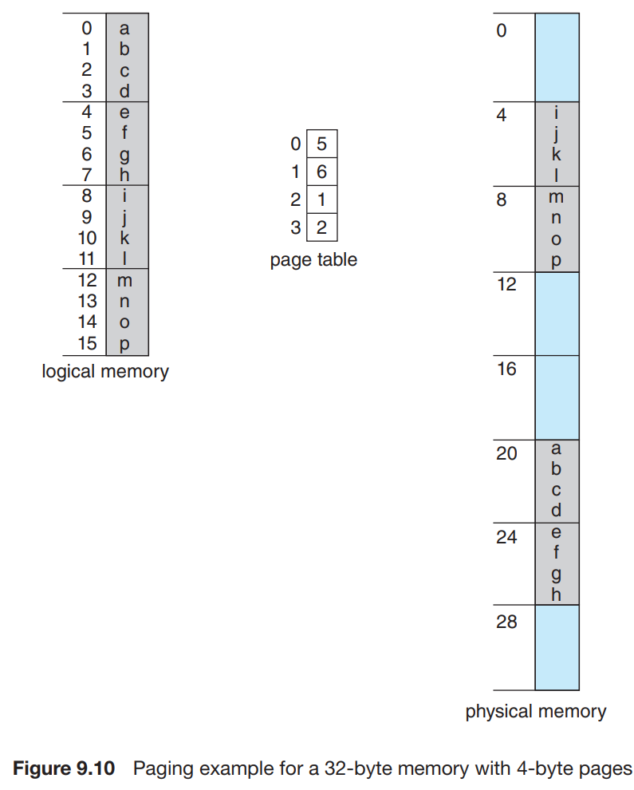

**Given:**

- Logical Address Space: 16 bytes (0 to 15) → requires `m=4` bits for addressing (2^4=16).
- Page Size: 4 bytes → requires `n=2` bits for the offset (2^2=4). Therefore, the page number (`p`) uses the high `m-n = 2` bits.
- Physical Memory: 32 bytes, divided into 8 frames (0 to 7) of 4 bytes each.
- Page Table: As shown in the figure, maps logical pages to physical frames.

**Address Translation Calculations:**

- **Logical Address 0:**
  - Binary: `0000`. High 2 bits `00` = Page 0. Low 2 bits `00` = Offset 0.
  - Page Table: Page 0 → Frame 5.
  - Physical Address = (Frame 5 * Page Size 4) + Offset 0 = (5 * 4) + 0 = **20**.
- **Logical Address 3:**
  - Binary: `0011`. High 2 bits `00` = Page 0. Low 2 bits `11` = Offset 3.
  - Page Table: Page 0 → Frame 5.
  - Physical Address = (5 * 4) + 3 = **23**.
- **Logical Address 4:**
  - Binary: `0100`. High 2 bits `01` = Page 1. Low 2 bits `00` = Offset 0.
  - Page Table: Page 1 → Frame 6.
  - Physical Address = (6 * 4) + 0 = **24**.
- **Logical Address 13:**
  - Binary: `1101`. High 2 bits `11` = Page 3. Low 2 bits `01` = Offset 1.
  - Page Table: Page 3 → Frame 2.
  - Physical Address = (2 * 4) + 1 = **9**.

#### **Paging as Dynamic Relocation**

Paging is a sophisticated form of **execution-time (dynamic) relocation**.

- Instead of a single **base register** for the whole process, paging uses a **page table**—which acts like **an array of base registers**, one for each logical page of the process.
- Each page table entry provides the "base address" (frame number) for its corresponding page.

#### **Fragmentation in Paging**

This is a key result:

- **External Fragmentation: ELIMINATED.**
  - Since any free **frame** anywhere can be used for any page, there is **no problem of needing a large contiguous free block**. Free memory is a **list of individual frames**, not a fragmented hole structure.
- **Internal Fragmentation: STILL EXISTS (but is manageable).**
  - Memory is allocated in **fixed-size frame units**. A process's last page is unlikely to be exactly full.
  - **Example:** Page size = 2048 bytes. Process size = 72,766 bytes.
    - Number of pages needed = ceil(72,766 / 2048) = ceil(35.53) = **36 pages**.
    - Memory allocated = 36 * 2048 = 73,728 bytes.
    - Internal Fragmentation = 73,728 - 72,766 = **962 wasted bytes** (in the last frame).
  - **Worst Case:** A process needing `n` pages + 1 byte gets `n+1` frames, wasting almost an entire frame.

**On average, internal fragmentation is about *half a page* per process.**

#### **The Page Size Trade-Off**

Choosing the page size is a critical design decision involving a trade-off:

- **Smaller Page Size:**
  - **Advantage:** Reduces **internal fragmentation** (wasted half-pages are smaller).
  - **Disadvantage:** **Increases the size of the page table.** More pages per process means more page table entries, increasing memory overhead for the tables themselves. Also can lead to more frequent page faults (discussed later).
- **Larger Page Size:**
  - **Advantage:** **Reduces page table size.** Fewer entries are needed.
  - **Advantage:** Improves **disk I/O efficiency** when reading/writing pages from/to disk (fewer, larger transfers are often faster).
  - **Disadvantage:** Increases **internal fragmentation**.

**Historical Trend & Modern Practice:** Page sizes have grown over time as memory sizes and datasets have increased. Today, the **standard page size is 4 KB or 8 KB**. However, to get the benefits of large pages for certain applications (like large databases), most modern systems support **multiple page sizes**.

- **x86-64 / Windows 10:** Supports 4 KB and **2 MB** "large pages".
- **Linux:** Supports the standard 4 KB page and **huge pages** (often 2 MB or 1 GB). Larger pages reduce page table overhead and TLB misses (you'll learn about the TLB next) for applications that use large, contiguous memory regions.

#### **Page Table Entry Size and Physical Memory Addressing**

A **Page Table Entry (PTE)** must store the physical **frame number** and additional control bits.

- **Typical Size:** On a **32-bit CPU**, a PTE is often **4 bytes (32 bits)** long.
- **Addressing Power:** With 32 bits, an entry can point to any of 2^32 different frames.
- **Maximum Physical Memory:** If frame size = 4 KB (2^12 bytes), then:
  - Physical address = (Frame Number * Frame Size) + Offset.
  - The frame number (32 bits) + offset (12 bits) = **44-bit physical address**.
  - This can address 2^44 bytes = **16 Terabytes (TB)** of physical memory.
- **Important Nuance:** The *maximum logical address space* for a single process (e.g., 32 bits = 4 GB) is **different** from the *total physical memory* the system can support (e.g., 16 TB). Paging decouples these two concepts.
- **Reduced Bits for Framing:** In reality, PTEs contain **extra control bits** (like valid/invalid, protection, dirty, reference) which use some of the 32 bits. This slightly **reduces the number of bits available for the frame number**, capping the addressable physical memory below the theoretical 16 TB maximum for a 4-byte PTE.

#### **Process Loading and Frame Allocation**

When a process is scheduled to run:

1. The OS checks the process size in **pages**.
2. It checks if at least that many **free frames** exist in physical memory.
3. If frames are available, the OS allocates them to the process. These frames can be **anywhere** in memory.
4. The OS loads each page from disk into its allocated frame.
5. For each page, the OS **creates an entry in the process's page table**, storing the allocated frame number.

**Go to Figure 9.11** in your book. This figure shows the process:

- **(a) Before Allocation:** A **free-frame list** (e.g., frames 13, 14, 18, 20, 15).
- **(b) After Allocation:** The new process's pages (0,1,2,3) are loaded into frames 14, 13, 18, 20 respectively. The free-frame list now only has frame 15. The process's **page table** is built with the mappings.

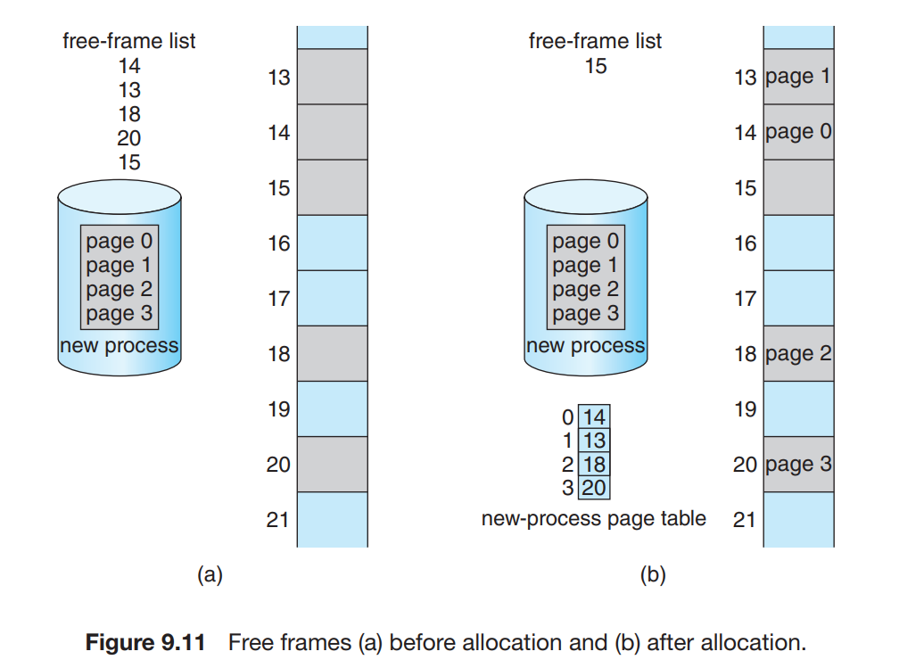

#### **The Paging Abstraction and Protection**

Paging creates a powerful **abstraction**:

- **Programmer/Process View:** A single, contiguous, private address space starting at address 0.
- **Physical Reality:** The process's code and data are **scattered** across various physical frames, intermingled with frames belonging to other processes.
- **The Enforcer:** The **address-translation hardware (MMU)** reconciles these views transparently. It is **impossible for a process to generate a physical address outside its own page table mappings**, providing strong memory protection automatically. A process cannot even name (address) memory belonging to the OS or other processes.

#### **Operating System Responsibilities**

The OS has crucial management duties:

**A. The Frame Table:**

- The OS maintains a **single, system-wide data structure called the frame table**.
- It has **one entry per physical frame** in the entire system.
- Each entry tracks: whether the frame is **free or allocated**, and if allocated, **which process and which page** of that process occupies it. (This is essential for page replacement algorithms in virtual memory).

**B. Managing Addresses in System Calls:**

- When a user process passes a memory address (e.g., a buffer pointer) as a parameter to a **system call** (like `read()` or `write()`), that address is a **logical address**.
- The OS (running in kernel mode) must **translate that logical address into the corresponding physical address** to access the correct user data. It does this by consulting the **process's page table**.

**C. Maintaining Process Page Tables:**

- The OS keeps a **master copy of each process's page table** in kernel memory.
- This copy is used for:
  1. Manual address translation during system calls.
  2. Setting up the **hardware page-table pointer** (e.g., the `CR3` register on x86) during a **context switch**—the dispatcher loads this register to point to the new process's page table before giving it the CPU.
- **Consequence:** Because the page table must be loaded/reloaded on each context switch, **paging increases context-switch time** compared to simpler schemes, as there is more hardware state to manage.

**Linux Tip: Obtaining Page Size** On a Linux system, you can find the system's page size via:

- **System Call:** Using `getpagesize()` in a C program.
- **Command Line:** Using the command `getconf PAGESIZE`. Both return the page size in bytes (e.g., 4096).

### **Section 9.3.2: Hardware Support**

#### **1. Page Tables as Process State**

The page table is a **critical piece of per-process hardware state**.

- A pointer to the process's page table (often called the **Page Table Base Register** or similar) is stored in the **Process Control Block (PCB)** along with the instruction pointer, general registers, etc.
- During a **context switch**, the OS scheduler's dispatcher must:
  1. Save the current process's page-table pointer.
  2. **Load the page-table pointer** of the next process to run into the appropriate hardware register.
  3. This tells the **MMU (Memory Management Unit)** where in physical memory to find the new process's mapping directory.

#### **2. Hardware Implementation Options for Page Tables**

There are two primary ways to implement the page table in hardware, representing a classic speed vs. flexibility trade-off.

##### **Option 1: Page Table in Dedicated Hardware Registers**

- **How it works:** The entire page table is stored in a set of **very high-speed registers** inside the CPU/MMU.
- **Advantage: Extremely fast translation.** Every address translation requires just a register lookup, which is nearly instantaneous.
- **Major Disadvantage: High context-switch overhead.** Switching to a new process requires **copying all page table entries from memory into these registers**, which is slow if the page table is large. This makes context switches very expensive.
- **Feasibility:** This is **only practical for very small page tables** (e.g., 256 entries or less). It was used in older or simpler architectures.

##### **Option 2: Page Table in Main Memory (The Standard Approach)**

- **How it works:** The page table is stored in **ordinary main memory (RAM)**.
- **Hardware Pointer:** A single, dedicated CPU register called the **Page-Table Base Register (PTBR)** holds the **starting physical address** of the page table in memory.
- **Advantage: Low context-switch overhead.** To switch processes, the OS only needs to **update the single PTBR** to point to the new process's page table in memory. This is very fast.
- **Disadvantage: Slower address translation.** *Every* memory access now logically requires **two physical memory accesses**:
  1. One to read the page table entry from memory (at the address `PTBR + p * entry_size`).
  2. A second to perform the actual desired read/write at the translated physical address. This would **halve performance**, which is intolerable.
- **The Crucial Solution:** The performance penalty of the two-memory-access problem is solved by a special high-speed cache called the **Translation Lookaside Buffer (TLB)**, which you will learn about next. The PTBR-in-memory scheme, combined with a TLB, is the standard in all modern systems.

#### **Section 9.3.2.1: Translation Look-Aside Buffer (TLB)**

##### **1. The Performance Problem with Memory-Resident Page Tables**

Storing the page table in main memory keeps context switches fast but creates a critical performance issue. Each memory access now logically requires:

1. **First Memory Access:** Read the **Page Table Entry (PTE)** from main memory (using the PTBR and page number `p`).
2. **Second Memory Access:** Perform the actual data read/write at the translated physical address.

This **doubles the memory access time**, which is unacceptable. A solution is needed to make translation **fast** while keeping page tables **large** and in memory.

##### **2. The Solution: TLB as a Translation Cache**

The **Translation Look-aside Buffer (TLB)** is the solution. It is a **special, small, extremely fast hardware cache** inside the MMU that stores recent page-to-frame translations.

- **Nature:** It is an **associative memory (content-addressable memory)**.
- **Entry Structure:** Each TLB entry has two parts:
  - **Key/Tag:** The **Virtual Page Number**.
  - **Value:** The corresponding **Physical Frame Number**, plus protection/status bits.
- **Operation:** When presented with a virtual page number, the TLB **compares it against all keys simultaneously**. If a match is found (a **TLB hit**), the corresponding frame number is returned **immediately**.
- **Size & Speed:** To be fast enough, the TLB must be small (typically **32 to 1024 entries**). Lookup is designed to be part of the CPU's **instruction pipeline**, adding **almost zero delay**.

##### **3. TLB Hit vs. TLB Miss**

**Go to Figure 9.12** in your book. This diagram shows the complete flow, which we will describe step-by-step.

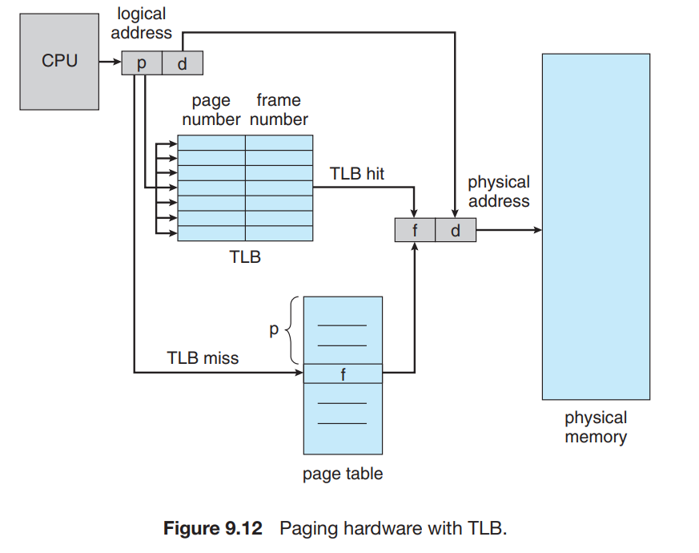

**Case A: TLB Hit**

1. CPU generates a logical address (page `p`, offset `d`).
2. MMU presents page `p` to the TLB.
3. TLB finds a matching entry (a **hit**).
4. MMU instantly retrieves the frame number `f`.
5. MMU forms physical address (`f` + `d`) and accesses memory. **This is as fast as a non-paged memory access.**

**Case B: TLB Miss**

1. CPU generates logical address.
2. MMU presents page `p` to the TLB.
3. TLB does **not** have an entry for `p` (a **miss**).
4. The MMU must now perform the **standard page table walk**: it uses the **PTBR** to find the page table in main memory and looks up the PTE for page `p`. **This requires one (or more) slow memory accesses.**
5. Once the frame number `f` is retrieved from memory, the MMU:
   - Uses it to form the physical address and access the data.
   - **Crucially, it adds the new mapping (`p` → `f`) to the TLB** for future use.
6. If the TLB is full, an **existing entry must be evicted** using a replacement policy (e.g., LRU, round-robin, random). Some OS-critical entries can be **wired down** (locked) to prevent eviction.

##### **4. Managing Multiple Processes: The ASID**

The TLB must correctly handle multiple processes, each with its own page table mapping the *same* virtual page numbers to *different* physical frames.

**Solution: Address-Space Identifiers (ASIDs)**

- An **ASID** is a unique number assigned to each process by the OS.
- Each TLB entry is tagged with the **ASID of the process** that owns the translation.
- During translation, the MMU checks that the ASID in the TLB entry **matches the ASID of the currently running process**.
- **If ASIDs match:** Translation is valid. ✅
- **If ASIDs don't match:** It's treated as a **TLB miss**, even if the page number matches. This prevents a process from using another process's translations.

**Without ASIDs:** The TLB must be **completely flushed (erased)** on *every* context switch to prevent the new process from using stale translations, causing many TLB misses after a switch. ASIDs allow the TLB to hold entries for **multiple processes simultaneously**, greatly improving performance.

##### **5. Performance Analysis: Hit Ratio and Effective Access Time**

- **Hit Ratio:** The percentage of memory accesses that result in a **TLB hit**. A high hit ratio (e.g., >99%) is crucial for performance.
- **Effective Memory-Access Time (EAT) Calculation:** We calculate the weighted average of hit and miss times.

**Example (Simplified):**

- Memory access time = 10 ns.
- TLB lookup time = 0 ns (assumed part of pipeline).
- **Hit Ratio = 80%**
  - **TLB Hit (80%):** Access memory once = 10 ns.
  - **TLB Miss (20%):** Access page table in memory (10 ns) + then access data (10 ns) = 20 ns.
  - **EAT = (0.80 × 10) + (0.20 × 20) = 12 nanoseconds.** (A 20% slowdown.)
- **Hit Ratio = 99%** (More realistic for a good TLB)
  - **EAT = (0.99 × 10) + (0.01 × 20) = 10.1 nanoseconds.** (Only a 1% slowdown.)

This shows why a high TLB hit ratio is essential—it makes paging overhead negligible.

##### **6. Modern Complexity: Multi-Level TLBs**

Modern CPUs (like Intel Core i7) have **hierarchical TLBs**, similar to multi-level CPU caches:

- **L1 TLB:** Very small and fast (e.g., 64-128 entries), split into **separate Instruction TLB (ITLB)** and **Data TLB (DTLB)**.
- **L2 TLB:** Larger but slower (e.g., 512-2048 entries), unified.
- On a miss in all TLBs, the CPU must perform a costly **page-table walk** in memory (hundreds of cycles) or trigger an OS handler.

##### **7. OS and Hardware Co-Design**

**TLBs are hardware, but the OS must be designed to use them optimally.**

- The OS designer **must understand the TLB characteristics** of the target CPU (size, replacement policy, ASID support).
- The OS's paging implementation (e.g., how it structures page tables) must align with the hardware's TLB and page-walking mechanisms.
- Changes in CPU TLB design across generations may require **changes in the OS** to maintain performance.

**In summary, the TLB is the essential hardware component that makes paging with memory-resident page tables viable by caching translations and achieving a very high hit rate, keeping the performance penalty of address translation extremely low.**

### **Section 9.3.3: Protection**

#### **1. Page-Level Protection Bits**

In a paged system, memory protection is integrated into the **page table entries (PTEs)**. Each PTE contains **protection bits** associated with its corresponding frame.

- **Basic Protection:** A common bit defines if the page is **read-only** or **read-write**.
- **Mechanism:** On **every** memory access, the MMU performs the address translation. As it retrieves the frame number from the PTE, it **simultaneously checks the protection bits**.
- **Violation:** If the access violates the protection (e.g., a write to a read-only page), the MMU triggers a **hardware trap (fault)** to the operating system, typically resulting in a **segmentation fault** for the offending process.
- **Extended Protection:** Hardware can support finer-grained bits, such as **execute-only** (common for security, to prevent data from being executed as code), or separate bits for read, write, and execute to allow any combination.

#### **2. The Valid-Invalid Bit**

One of the most important protection bits is the **valid-invalid bit**.

- **Valid (`v`):** Indicates that the page is **within the process's logical address space** and is **a legal page** that the process is allowed to access.
- **Invalid (`i`):** Indicates that the page is **not within the process's logical address space**. An access to such a page is **illegal** and causes a trap to the OS.

The OS sets this bit for each page table entry when setting up or modifying a process's address space.

#### **3. Concrete Example: Valid vs. Invalid Pages**

**Go to Figure 9.13** in your book. Let's analyze this example carefully.

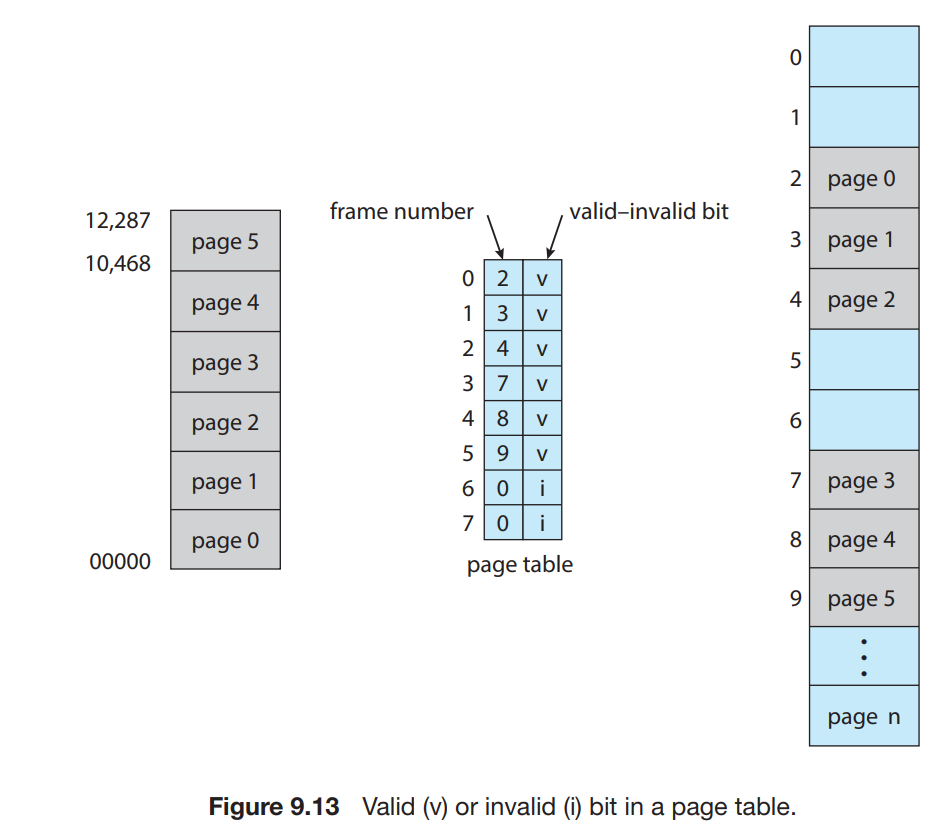

- **System Specs:** 14-bit logical address space → addresses 0 to 16383. Page size = 2 KB (2048 bytes).
- **Program Size:** Uses addresses 0 to 10468 only.
- **Page Calculation:**
  - Page size = 2048 bytes.
  - Program uses ceil(10469 / 2048) = ceil(5.11) = **6 pages** (Pages 0-5).
  - However, the full 14-bit address space contains 16384 / 2048 = **8 pages** (Pages 0-7).
- **Page Table Setup (See Figure):**
  - Entries for Pages 0-5 are marked **valid (`v`)**. They map to some physical frames.
  - Entries for Pages 6 and 7 are marked **invalid (`i`)**.
- **Address Validation:**
  - Access to address 5000 (in Page 2): **Valid** → Allowed.
  - Access to address 12288 (first byte of Page 6): **Invalid** → Trap to OS.
- **The "Problem" / Nuance:** Notice that the **last valid page (Page 5)** contains addresses 10240 to 12287. Since the program only goes up to 10468, **addresses 10469 through 12287 in Page 5 are also "illegal" for the program, but are still marked as valid.** This is because protection is enforced at the **page granularity**, not byte granularity. The invalid region starts only at the next page boundary (Page 6). This is a direct consequence of **internal fragmentation**—the entire last page (Page 5) is allocated, even though part of it is unused.

#### **4. The Page-Table Length Register (PTLR)**

Storing entries for *all* possible pages in a large address space (e.g., 2^20 entries for a 32-bit space with 4KB pages) is wasteful if a process uses only a small fraction.

- **Hardware Support:** Some architectures provide a **Page-Table Length Register (PTLR)**.
- **Function:** The PTLR holds the **size (number of entries)** of the current process's page table.
- **Protection Check:** For every logical address, the hardware compares the extracted **page number (`p`)** against the PTLR value.
  - If `p` ≥ PTLR, the page number is **out of bounds**, causing an immediate trap. This check happens *before* the page table lookup.
- **Benefit:** This allows the OS to allocate a page table **only as large as needed** for the process's highest-used page, saving memory. Entries for higher, unused page numbers simply don't exist.

**Summary:** Paging provides natural and efficient memory protection. The **protection bits** control the type of access (read/write/execute), the **valid-invalid bit** defines the legal address space, and hardware like the **PTLR** can optimize table size. Protection is enforced automatically by the MMU on every access, trapping any violation to the OS.

### **Section 9.3.4: Shared Pages**

#### **1. The Need for Sharing Code**

A major advantage of paging is the ability for **multiple processes to share identical code** in physical memory. This is crucial for system libraries used by almost every program (like the standard C library, `libc`).

- **Without Sharing:** If 40 processes each load their own 2 MB copy of `libc`, total memory use = **80 MB**.
- **With Sharing:** If all 40 processes share **one** physical copy of `libc`, total memory use for the library = **only 2 MB**. This is a dramatic saving.

#### **2. Requirement: Reentrant (Pure) Code**

Sharing is only possible for **reentrant code (also called pure code or non-self-modifying code)**.

- **Definition:** Code that **never changes during execution**. It contains only **instructions** (no self-modifying instructions) and **constants**. Any process-specific data must be stored in a **separate, private data section**.
- **Why?** If shared code were modifiable, one process could change an instruction, corrupting execution for all other sharing processes.
- **Enforcement:** The OS must enforce this by marking shared code pages as **read-only** in the page table protection bits. A write attempt by any process will trigger a protection fault.

#### **3. How Page Sharing Works**

**Go to Figure 9.14** in your book. This illustrates the mechanism.

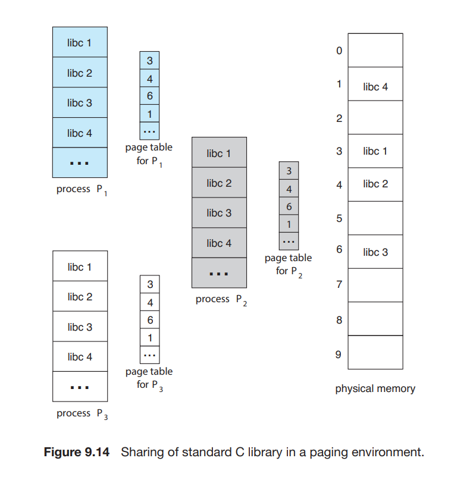

#### **4. What Can Be Shared?**

- **System Libraries:** The primary use case (e.g., `libc`, `libm`).
- **Common Programs:** Compilers, database systems, window system code.
- **Shared Memory (IPC):** Some operating systems implement the **shared memory** interprocess communication mechanism (from Chapter 3) using **shared pages**. Processes can map a region of their address space to the same physical pages to exchange data at memory speed.
- **Kernel Code:** The kernel itself is often shared among all processes via paging, mapped into a protected region of every address space.

#### **5. Relation to Other Concepts**

- **Dynamic Linking & Shared Libraries (Section 9.1.5):** This is the **implementation mechanism**. When a program is dynamically linked to `libc`, the OS loader sets up the process's page table to **map to the already-loaded, shared physical pages** of `libc`, rather than loading a separate copy.
- **Threads (Chapter 4):** Threads within the same process **naturally share all code and data pages** of their process, which is an even tighter form of memory sharing.
- **Virtual Memory Benefits (Chapter 10):** This sharing capability is one of several powerful benefits enabled by the paging abstraction, which you will explore further.

**In summary, shared pages via paging enable massive memory savings and efficient program construction by allowing multiple processes to map their logical pages to the same physical frames containing reentrant code, enforced by hardware protection bits.**

## **Section 9.4: Structure of the Page Table**

#### **1. The Problem: Large Page Tables**

Modern systems have huge logical address spaces (32-bit to 64-bit). This leads to **massive page tables** if implemented as a simple linear array.

**Example (32-bit system, 4 KB pages):**

- Logical Address Space: 2^32 bytes.
- Page Size: 2^12 bytes (4 KB).
- Number of Pages: 2^32 / 2^12 = **2^20 = ~1 million pages**.
- Page Table Size: 1 million entries * 4 bytes per entry = **4 MB per process**. Allocating 4 MB of **contiguous physical memory** for each process's page table is wasteful and impractical. We need smarter page table structures.

### **Section 9.4.1: Hierarchical Paging (Multi-Level Page Tables)**

#### **1. The Core Idea: Page the Page Table**

The solution is to apply paging to the **page table itself**. Instead of one huge, contiguous page table, we break it into smaller pieces (pages) and only keep the needed pieces in memory. This creates a **hierarchical (tree-like) structure**.

#### **2. Two-Level Paging (Forward-Mapped Page Table)**

This is the most common hierarchical scheme for **32-bit architectures**.

**Go to Figure 9.15** in your book for a visual of the structure, and **Figure 9.16** for the translation process.

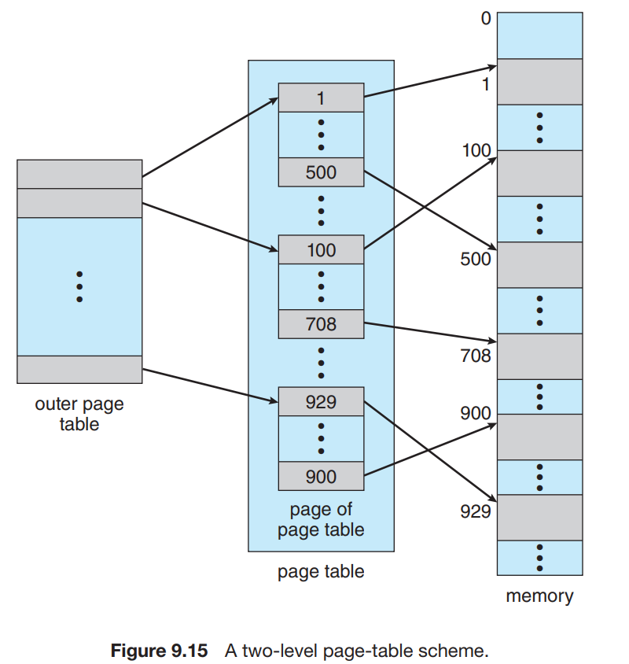

**Example (32-bit address, 4 KB pages):**

- Logical address split originally: 20-bit page number (`p`), 12-bit offset (`d`).
- **New Split with Two-Level Paging:**
  - Divide the 20-bit page number further:
    - `p1` (10 bits): Index into the **outer page table** (also called the **page directory**).
    - `p2` (10 bits): Index into an **inner page table** (a page of page-table entries).
  - `d` (12 bits): Page offset (unchanged).

```
Logical Address: | p1 (10 bits) | p2 (10 bits) | d (12 bits) |
```

**How Translation Works (Follow Figure 9.16):**

1. The **Page-Directory Base Register (PDBR)** holds the physical address of the **outer page table**.
2. Use `p1` as an index into the outer page table. This entry gives the physical address of the **inner page table page**.
3. Use `p2` as an index into that inner page table page. This entry gives the **physical frame number** of the desired data page.
4. Combine this frame number with offset `d` to get the final physical address.

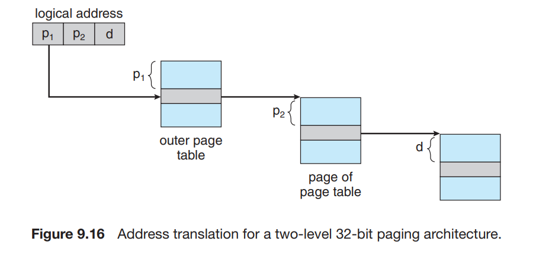

**Advantages:**

- **No large contiguous allocation needed.** The outer table is small (e.g., 2^10 entries = 4 KB), and inner table pages are allocated only as needed.
- **Saves memory.** If a process uses only a sparse region of its address space, only the corresponding inner page tables need to be allocated. Unused regions just have invalid entries in the outer table.

#### **3. The 64-Bit Address Space Problem**

For 64-bit architectures, two-level paging becomes insufficient.

**Example (64-bit, 4 KB pages):**

- Logical Address Space: 2^64 bytes (massive).
- Page Size: 2^12 bytes.
- Number of Pages: 2^(64-12) = **2^52 pages** (over 4 quadrillion).
- Even with two-level paging:
  - Let inner table fit in one page (1024 entries = 10 bits for `p2`).
  - Then outer table needs 2^(52-10) = **2^42 entries**.
  - That's **16 Terabytes** just for the outer page table! This is obviously impossible.

#### **4. Deeper Hierarchies: Three-Level and Beyond**

The solution is to add more levels, paging the outer tables themselves.

- **Three-Level Paging:** Outer page table → Middle page table → Inner page table → Data Page.
- **Four-Level Paging:** Adds another level.
- **Extreme Case (64-bit UltraSPARC):** Required **seven levels** of paging.

**The Major Drawback:** Each additional level adds **one extra memory access** for translation (unless cached in the TLB). With seven levels, a single memory access could theoretically require **eight memory reads** (seven for page tables, one for data), which is prohibitively slow.

#### **5. Conclusion for Hierarchical Paging**

- **Appropriate for:** 32-bit systems (typically 2 levels) and some 64-bit systems with a limited virtual address width (e.g., 48-bit, using 3-4 levels).
- **Inappropriate for:** Full 64-bit address spaces with many levels, due to high translation overhead and table size.

**This limitation for 64-bit systems motivates alternative page table structures like Hashed Page Tables and Inverted Page Tables, which you will study next.**

### **Section 9.4.2: Hashed Page Tables**

#### **1. Motivation: Handling Large Address Spaces**

Hierarchical page tables become inefficient for very large (e.g., full 64-bit) address spaces due to excessive depth or table size. The **Hashed Page Table** is an alternative structure designed for these large spaces. It uses a **hash table** data structure to store page table entries.

#### **2. Structure of a Hashed Page Table**

The core idea is to use the **virtual page number** as a key to hash into a table.

- **Hash Table:** An array of buckets, each being the head of a **linked list** (to handle hash collisions).
- **Linked List Entry (Element):** Each node in the list contains three fields:
  1. **Virtual Page Number:** The key used for exact matching.
  2. **Mapped Physical Frame Number:** The translation value.
  3. **Pointer to Next Element:** For collision chaining.

**Go to Figure 9.17** in your book. This figure shows the translation flow: the virtual page number (`p`) is hashed, leading to a bucket and a linked list traversal to find the matching entry, yielding the frame number (`r`).

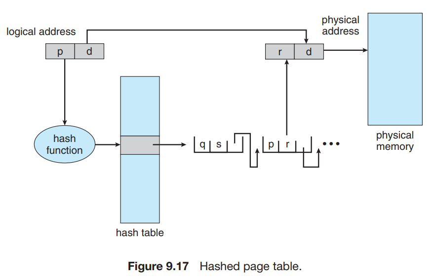

#### **3. Translation Algorithm**

For a given logical address (virtual page number `p`, offset `d`):

1. **Hash:** Apply a **hash function** to the virtual page number `p`. This produces an **index into the hash table**.
2. **Traverse the Linked List:** Go to the corresponding bucket (linked list). Traverse the list, comparing the virtual page number `p` with the **Virtual Page Number field (1)** in each entry.
3. **Match Found (Hit):** When a matching entry is found, extract the **Physical Frame Number (field 2)**. Combine it with offset `d` to form the physical address.
4. **No Match (Miss):** If the end of the list is reached without a match, it's a **page fault** (the page is not in memory), triggering the OS page-fault handler.

#### **4. Advantages and Considerations**

- **Efficient for Sparse Address Spaces:** It only allocates memory for entries that actually exist (i.e., pages that are valid and in memory), unlike hierarchical tables which allocate whole pages of entries.
- **Potentially Constant Lookup Time:** With a good hash function and low collisions, average lookup time can be near O(1), though worst-case (many collisions) can be O(n) for list length.
- **Hardware/Software Cooperation:** Often, the hash table is **managed by the operating system** in software. The **hardware (MMU) may have a dedicated register** pointing to the start of the hash table. On a TLB miss, a **hardware page-table walker** unit may perform this hash lookup in hardware, or it may trap to an OS software handler.

#### **5. Enhancement: Clustered Page Tables**

A variation designed specifically for **64-bit address spaces**.

- **Key Difference:** Each entry in the hash table (each node in the linked list) maps **not just one, but a cluster of consecutive virtual pages** (e.g., 16 pages) to a corresponding set of physical frames.
- **Why it Helps:**
  - **Reduces Table Size:** A single entry can store 16 mappings, shrinking the total number of required entries.
  - **Improves Locality:** If a process accesses a virtual page, it's likely to access neighboring pages soon. A clustered entry brings those translations into the TLB or cache together.
  - **Excellent for Sparse Addresses:** Even if references are scattered, grouping them into clusters minimizes the number of separate hash table entries needed.
- **Use Case:** Ideal for very large, **sparse address spaces** where memory references are noncontiguous and spread out over vast virtual memory ranges.

### **Section 9.4.3: Inverted Page Tables**

#### **1. The Problem with Standard Page Tables**

Standard (forward) page tables have one entry **per virtual page per process**. In a system with many processes and huge address spaces, the **combined size of all page tables** can consume a significant portion of physical memory itself. This is wasteful.

#### **2. The Core Idea of Inverted Page Tables**

The inverted page table takes a radically different approach.

- **It has only one system-wide page table.**
- It has **exactly one entry for each physical frame (page frame)** in the system's RAM.
- **Each entry tells us:** Which process's *virtual page* is currently occupying this physical frame.

**Contrast:** A standard page table maps Virtual Page → Physical Frame. An inverted page table maps **Physical Frame → (Process, Virtual Page)**.

**Go to Figure 9.18** in your book and compare it with Figure 9.8. This highlights the inversion: instead of many tables indexed by virtual page number, there is one table indexed by physical frame number.

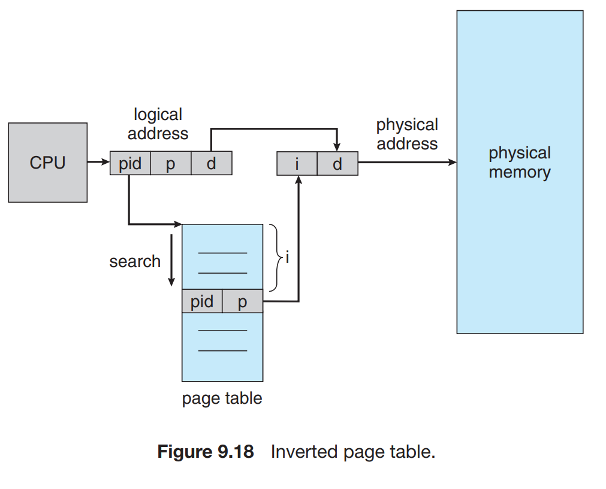

#### **3. Structure and Translation Process**

**Entry Format:** Each entry contains:

1. **Process Identifier (PID) / Address-Space Identifier (ASID):** Identifies the process that owns the page.
2. **Virtual Page Number:** The virtual page from that process's address space that is stored in this frame.

**Logical Address Format:** Becomes a triple: `<Process-ID, Virtual-Page-Number, Offset>`.

**Translation Algorithm (Given a logical address `<pid, p, d>`):**

1. **Search:** The system must **search the entire inverted page table** for an entry where `(PID == pid) AND (Virtual-Page-Number == p)`.
2. **Match Found:** If found at entry `i`, then `i` **is the physical frame number**. The physical address is `<i, d>`.
3. **No Match:** If not found, it's a **page fault** (the page is not in memory).

**The Critical Performance Problem:** The inverted page table is **sorted/organized by physical frame number**, but we need to look up by **virtual address**. This necessitates a **linear search through the entire table** on every translation—impossibly slow for systems with millions of frames.

#### **4. The Solution: Hashing (Combining with Section 9.4.2)**

To make inverted page tables practical, they are **always used with a hash table**.

- The hash function takes the `<pid, p>` pair as input.
- The hash table points to entries (or chains of entries) in the inverted page table where that virtual address *might* be located.
- This reduces the search from scanning the whole table to checking just one or a few entries in a linked list.

**Performance Note:** Even with hashing, a TLB miss now requires **at least two memory accesses**: one to the hash table and one to the inverted page table entry (plus the final data access). This is slower than a hierarchical page table walk, making the **TLB hit ratio even more critical**.

#### **5. The Shared Memory Problem**

This is a significant **drawback** of inverted page tables.

- **In Standard Paging:** Multiple processes can map **different virtual pages** to the **same physical frame** (shared memory, shared libraries). Each process has its own page table entry pointing to the shared frame.
- **In Inverted Page Tables:** There is **only one entry per physical frame**. That entry can only store **one `<pid, virtual-page>` pair**. Therefore, **only one process at a time can have that frame mapped into its address space**.
- **Consequence:** True sharing, where multiple processes simultaneously map the same frame, is **not directly supported**. If a second process tries to access shared memory, it will cause a page fault. The OS could handle this by mapping a *different* physical frame and copying data, breaking true sharing, or by complex workarounds, making shared memory inefficient.

#### **6. Usage**

Despite the shared memory limitation, inverted page tables are used in some major **64-bit architectures** (like older **PowerPC/Power** and **UltraSPARC**) where the memory savings from having a single, small table outweighed the drawbacks for their target workloads. Modern x86-64 systems, however, use **multi-level hierarchical page tables**, often with a hashed walker for upper levels, to better support features like shared memory.

### **Section 9.4.4: Oracle SPARC Solaris (Case Study)**

#### **1. Introduction: A Modern 64-Bit Integrated Design**

This section examines a real-world, high-performance system: **Solaris OS on SPARC CPUs**. It's a tightly integrated 64-bit design that must manage huge virtual address spaces without wasting physical memory on page tables. Its solution is an efficient, hybrid approach centered around **hashed page tables**.

#### **2. Core Structure: Hashed Page Tables with "Mapped Regions"**

Solaris/SPARC uses **hashed page tables**, but with a key optimization:

- **Two Separate Hash Tables:**
  1. **Kernel Hash Table:** For the kernel's address space.
  2. **User Process Hash Table:** Shared by all user processes (this is essentially an **inverted page table** structure, as it maps physical frames to owning virtual addresses).
- **Entry Granularity (The Optimization):** Each hash table entry does **not** represent a single 4KB page. Instead, it represents a **contiguous area of mapped virtual memory** (a region of many pages).
  - Each entry contains:
    - **Base Virtual Address**
    - **Span:** The number of pages in this contiguous region.
- **Benefit:** This is far more efficient for large, contiguous mappings (common for code segments, large data arrays) as a **single hash entry can cover megabytes of memory**, drastically reducing the total number of required entries.

#### **3. The Multi-Level Translation Hierarchy**

The system uses a multi-tiered caching structure for translation, designed to make the common case (TLB hit) extremely fast, while handling misses efficiently.

**Follow this translation flow:**

**Level 1: Translation Lookaside Buffer (TLB)**

- **Purpose:** The **fastest** hardware cache on the CPU chip, holding the most recently used **Translation Table Entries (TTEs)**.
- **Action on memory access:** The MMU checks the TLB first.
  - **TLB Hit:** Translation is immediate → Physical address formed → Access proceeds. **(This is the common, fast path.)**
  - **TLB Miss:** Proceed to Level 2.

**Level 2: Translation Storage Buffer (TSB)**

- **What it is:** A **larger, software-managed cache of TTEs** kept in **main memory**. It's essentially a **direct-mapped cache** for page table entries.
- **Action on TLB Miss:** The CPU's hardware **page-table walker** automatically searches the in-memory TSB for the TTE corresponding to the faulting virtual address. This is a **hardware walk**, not a software interrupt.
  - **TSB Hit:** The hardware **copies the TTE from the TSB into the TLB**. The translation then completes, and the memory access retries (which will now TLB hit).
  - **TSB Miss:** Proceed to Level 3.

**Level 3: Kernel Hash Table Walk (Software)**

- **Action on TSB Miss:** The hardware triggers an **interrupt** to the **kernel**.
- The kernel's page-fault handler now performs a **software search** in the appropriate **hashed page table** (user or kernel) to find the mapping.
- Once found, the kernel:
  1. **Creates a TTE** for the mapping.
  2. **Stores this TTE into the TSB** (so future misses on this page will TSB-hit).
  3. Possibly **loads it directly into the TLB**.
- The interrupt handler returns, the MMU retries the translation (which will now succeed via TLB or TSB), and the original instruction proceeds.

#### **4. Summary and Key Takeaways**

This design exemplifies sophisticated, real-world memory management:

1. **Hybrid Structure:** Uses **hashed page tables** (with region granularity) as the primary, space-efficient backing store.
2. **Multi-Level Caching:** Employs a hierarchy (**TLB → TSB → Hash Table**) to optimize performance. The **TSB** is a critical intermediary that offloads many misses from costly kernel interrupts to a faster hardware-managed walk.
3. **Hardware/Software Co-Design:** The **hardware (MMU)** knows about and can walk the **software-defined TSB** structure. The **kernel** manages the hash tables and handles the slowest misses. This tight integration is key to performance on 64-bit systems.
4. **Efficiency for Large Mappings:** Using hash entries that cover large contiguous regions reduces table size and improves TSB/TLB effectiveness for workloads with big, contiguous memory areas.

This case shows how advanced OSes solve the page table scalability problem through a combination of intelligent data structures (hashed, region-based tables) and multi-tiered caching (TLB, TSB), with close cooperation between CPU hardware and operating system software.

## **Section 9.5: Swapping**

#### **1. The Basic Concept of Swapping**

A core principle is that instructions/data must be in **main memory (RAM)** for the CPU to execute them. **Swapping** is a technique where the OS can temporarily move a **process (or part of a process)** out of RAM to a **backing store** (usually a disk) and later bring it back.

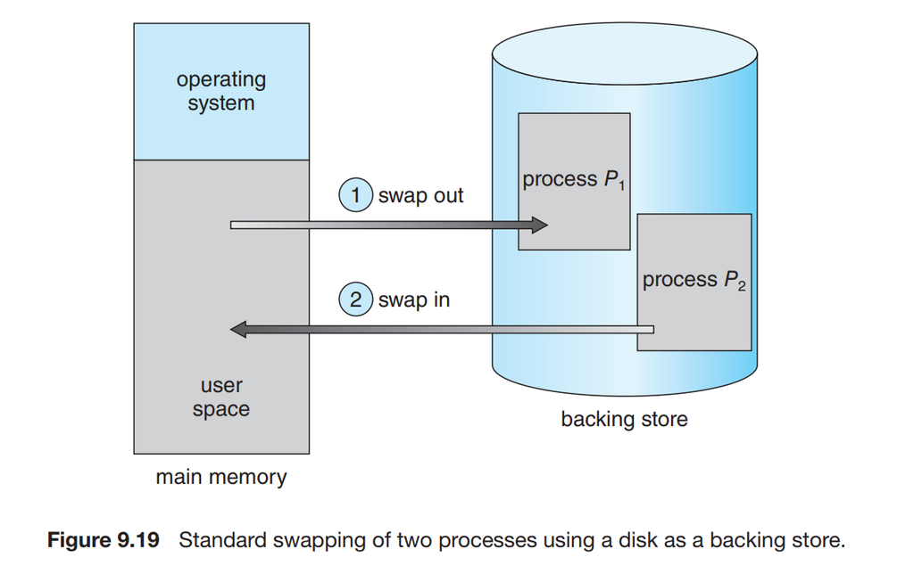

### **Section 9.5.1: Standard Swapping (Whole-Process Swapping)**

#### **How It Works**

- The **entire address space** of a process (code, data, stack, heap) is copied as a single contiguous unit between physical memory and the backing store.
- The backing store must be **fast** (traditionally a dedicated disk partition or fast SSD) and support **direct access** to quickly read/write these large memory images.
- For **multithreaded processes**, all **per-thread data** (stacks, thread control blocks) must also be swapped.
- The OS maintains **metadata** (process state, location on disk, memory size) for swapped-out processes to restore them later.

#### **Advantage and Use Case**

- **Advantage:** Enables **memory oversubscription**. The system can run more processes than physically fit in RAM at once.
- **Ideal Candidate:** **Idle or low-priority processes**. Their memory can be reclaimed for active processes. When they become active again, they are swapped back in.

#### **The Major Drawback: Performance**

- The time to copy an **entire process** (which could be many megabytes) to/from disk is **prohibitive**. The process is completely frozen during this transfer, and system responsiveness suffers.
- **Modern Status:** **Rarely used** in contemporary general-purpose OSes due to this high cost. An exception is **Solaris**, which uses it only as a last-resort emergency measure under extreme memory pressure.

### **Section 9.5.2: Swapping with Paging (The Modern Standard)**

#### **The Evolution: From Processes to Pages**

Because whole-process swapping is too slow, modern systems use a refined technique: **Swapping with Paging**, usually just called **Paging** (or **Demand Paging**, covered in Chapter 10).

- **Unit of Transfer:** Instead of moving an entire process, the OS moves **individual pages** (or small groups of pages) between memory and the backing store.
- **Terminology:**
  - **Page out:** Move a page from RAM to the backing store.
  - **Page in:** Move a page from the backing store back into a free frame in RAM.
- **Visualization: Go to Figure 9.20.** This illustrates the modern view: Processes A and B have only a subset of their pages in physical memory. Some pages of A are being **paged-out**, while some pages of B are being **paged-in**. Memory is a collection of frames holding pages from various processes.

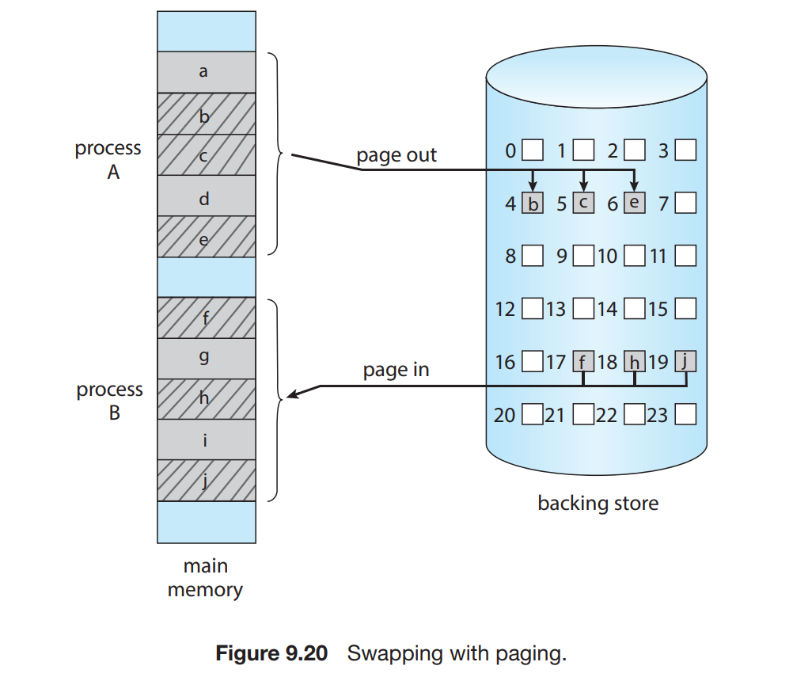

#### **Advantages Over Standard Swapping**

1. **Granularity & Speed:** Transferring a **single 4KB page** is vastly faster than transferring an entire 100MB process. This reduces the latency felt by individual processes.
2. **Efficiency:** Only the **actively used** portions of a process need to reside in memory. Large, unused sections (like error handling code) may never be paged in.
3. **Flexibility:** The OS can page out only the **least-used pages** from any process, not necessarily the entire least-used process. This leads to more efficient memory utilization.
4. **Foundation for Virtual Memory:** This paging mechanism is the **core implementation of virtual memory**, which provides the illusion of an extremely large logical address space to each process, regardless of physical RAM size.

#### **Relationship to Virtual Memory**

- Swapping with paging is **not virtual memory itself**, but the **essential mechanism** that makes virtual memory possible.
- **Chapter 10 (Virtual Memory)** will dive deep into the policies (like **demand paging** and **page replacement algorithms**) that decide **which pages** to page in/out and **when** to do it, optimizing this process.

**In summary, while "swapping" historically meant moving whole processes, in modern systems it refers to the **paging** of individual pages to/from disk. This is the critical mechanism that allows systems to efficiently oversubscribe physical memory, supporting more and larger applications than would otherwise be possible.**

### **Section 9.5.3: Swapping on Mobile Systems**

#### **1. The Mobile Constraint: No Traditional Swapping**

Unlike PC/server OSes, **mobile operating systems (iOS, Android) typically do NOT support swapping or paging** to storage. This is a fundamental design difference due to hardware constraints.

**Primary Reasons:**

1. **Storage Medium:** Mobile devices use **flash memory (eMMC, UFS, NVMe)** for storage, not hard disks. While spacious, it has critical limitations.
2. **Write Endurance:** Flash memory cells wear out after a finite number of write/erase cycles. Frequent paging operations (writing dirty pages to storage) would **severely shorten the device's lifespan**.
3. **Throughput & Latency:** The I/O path between main memory (RAM) and flash storage on mobile SoCs (System-on-a-Chip) is often **slower** relative to their RAM speed than on PCs/servers, making swapping performance even more punitive.
4. **Power Consumption:** Frequent flash writes consume significant battery power.

#### **2. Mobile OS Strategies for Memory Pressure**

Since they cannot swap, mobile OSes use alternative, more aggressive methods to free memory when it runs low.

##### **Apple's iOS Approach:**

- **Memory Pressure Notifications:** When free memory is critically low, the OS **notifies running applications** and asks them to **voluntarily free up memory** (e.g., purge caches, release unused objects).
- **Handling Read-only Data:** The OS can **unload read-only data** (like code pages) from RAM. Since the original is unchanged on flash, it can be reloaded later if needed.
- **Never Removing Dirty Data:** Modified data (stack, heap) is **never written to flash** due to wear concerns.
- **The Ultimate Sanction:** If an app fails to free enough memory, the OS **terminates it**.

##### **Android's Approach:**

- **Process Termination (Low Memory Killer):** Android maintains a hierarchy of process importance (foreground app, visible service, background app, etc.). Under memory pressure, it starts **terminating processes from least important to most important**.
- **Application State Preservation:** Before terminating a process, Android **writes the application's state (UI state, variables)** to flash. This allows the app to be **quickly restarted** to its previous state when the user returns to it, improving the user experience despite the termination.
- **Developer Responsibility:** The `onSaveInstanceState()` callback in Android is part of this mechanism.

##### **Consequence for Mobile Developers:**

Developers **must** write **memory-efficient code**. **Memory leaks** (failure to release unused memory) or excessive memory use are much more critical on mobile, as they directly lead to **app termination (iOS)** or **being killed first (Android)**, degrading user experience.

#### **3. Figure Reference: Swapping with Paging**

**Go to Figure 9.20** in your book. While this figure illustrates the **swapping with paging** mechanism used on desktops/servers, it highlights what mobile systems *do not do*. They avoid the constant page-out/page-in cycle between RAM and flash storage shown here.

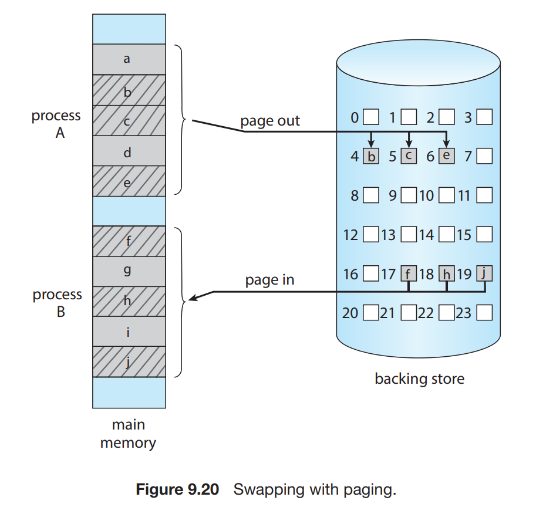

#### **System Performance Under Swapping (General Note)**

The presence of any swapping activity (page-outs) is a **warning sign** that the system has **more active processes/pages than available physical RAM**. This leads to constant disk I/O ( **thrashing**), severely degrading performance.

**The two straightforward solutions are:**

1. **Reduce Demand:** Terminate some processes (the mobile approach).
2. **Increase Supply:** Add more physical RAM (the PC/server approach).

This highlights that swapping/paging is a **useful illusion** for oversubscription, but it is **not a substitute for having adequate physical memory**. When swapping becomes frequent, performance collapses.

## **section 9.6: Example: Intel 32- and 64-bit Architectures**

#### **1. Introduction: The Dominant PC Architecture**

Intel's x86 architecture has been the foundation of personal computing for decades. Its evolution provides a concrete, real-world case study of memory management hardware.

- **Historical Progression:** 16-bit (8086/8088) → 32-bit (**IA-32**, Pentium family) → 64-bit (**x86-64**).
- **Ubiquity:** Runs major OSes: Windows, macOS, Linux.
- **Mobile Exception:** Intel is not dominant in mobile, where **ARM** architecture prevails (see Section 9.7).
- **Scope of Discussion:** We'll cover the **major memory-management concepts** of IA-32 and x86-64. Note that there are many variations and versions across CPU generations.

### **Section 9.6.1: IA-32 Architecture (32-bit)**

#### **1. The Two-Stage Address Translation**

The IA-32 memory management is a **hybrid scheme combining Segmentation and Paging**. Both are always used together in protected mode (the standard operating mode for modern OSes).

The translation pipeline has **two distinct hardware units**:

1. **Segmentation Unit**
2. **Paging Unit**

Together, they form the complete **Memory Management Unit (MMU)**.

#### **2. Translation Pipeline**

**Logical Address → [Segmentation Unit] → Linear Address → [Paging Unit] → Physical Address**

- **Step 1: Logical to Linear Address (Segmentation)**
  - The CPU generates a **logical address**. This is a **pair**: a **Segment Selector** (identifying a segment) and an **Offset** within that segment.
  - The **Segmentation Unit** uses the selector to look up a **Segment Descriptor** in a table (GDT or LDT). This descriptor contains the segment's **base linear address**, limit, and protection bits.
  - The unit adds the **offset** to the **segment base** to produce a **linear address**. It also checks the offset against the segment limit for protection.
- **Step 2: Linear to Physical Address (Paging)**
  - The **linear address** is a **32-bit value** that is the input to the paging hardware.
  - The **Paging Unit** takes this linear address and, using the **page table structures** (typically a **two-level page table**), translates it into a **physical address**.

#### **3. Visual Reference**

**Go to Figure 9.21** in your book. This figure illustrates the complete two-stage translation process described above, showing the flow from the logical address (selector:offset) through the segmentation and paging units to the final physical address.

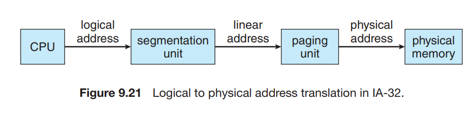

#### **4. Key Implications for the OS**

- **OS Design Choice:** While the hardware supports full segmentation, most modern OSes (like Windows and Linux) **minimize its use** to simplify memory management. They often set up segments with a **base of 0 and a limit of 4GB**, effectively making the **logical address equal to the linear address** (offset = linear address). This effectively **bypasses segmentation** for flat memory models.
- **Paging is Primary:** The **paging unit** does the heavy lifting of modern memory management (virtual memory, protection, sharing). The segmentation stage is largely a historical artifact that must be configured but is often neutralized.
- **Protection from Both Stages:** Protection can be enforced at both stages: segment limits and permissions in the segmentation unit, and page-level read/write/execute bits in the paging unit.

**In summary, IA-32 uses a mandatory two-stage translation (Segmentation + Paging), but operating systems typically configure it to implement a flat address space where paging provides all the important features of virtual memory.**

#### **Section 9.6.1.1: IA-32 Segmentation **

##### **1. Segmentation Model Overview**

The IA-32 segmentation model provides each process with a **two-part logical address space** composed of segments.

- **Segment Capacity:** A single segment can be up to **4 GB** in size.
- **Total Segments per Process:** Up to **16,384 (16K)** segments.
- **Two Partitions:**
  1. **Private Segments (Up to 8K):** Belong only to the process. Descriptors stored in the **Local Descriptor Table (LDT)**.
  2. **Shared Segments (Up to 8K):** Shared among all processes. Descriptors stored in the **Global Descriptor Table (GDT)**. The OS kernel and shared libraries typically reside here.
- **Descriptor Tables (LDT & GDT):** These are **arrays of 8-byte Segment Descriptors** stored in memory. Each descriptor fully defines one segment: its **32-bit base linear address**, its **limit (size)**, and its **protection/type attributes**.

##### **2. The Logical Address Format: (Selector, Offset)**

A logical address is not a single number but a **pair**:

- **Selector (16 bits):** An index into a descriptor table. Its format is:

  ```
  | Index (13 bits) | Table Indicator (1 bit) | Requested Privilege Level (2 bits) |
  ```

  - **Index (bits 3-15):** The segment number (0 to 8191). This selects one of the 8K entries in the LDT or GDT.
  - **Table Indicator - TI (bit 2):** 0 = Use the **GDT**. 1 = Use the **LDT**.
  - **Requested Privilege Level - RPL (bits 0-1):** The CPU's current privilege level, used for protection checks.
- **Offset (32 bits):** The byte address *within* the selected segment.

**Visual Reference: Go to Figure 9.22.** This shows the translation from the (selector, offset) pair to a linear address using the descriptor tables.

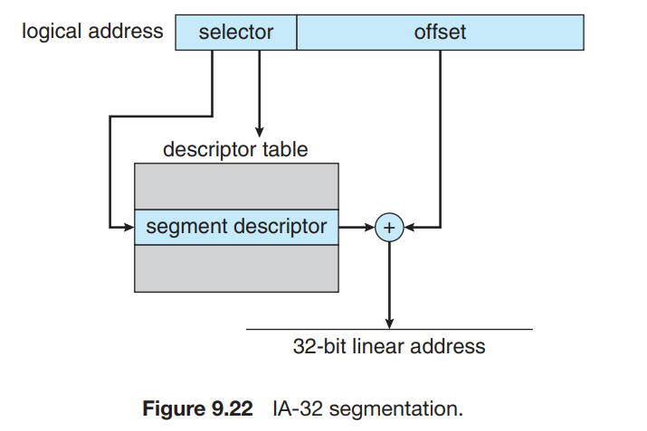

##### **3. Hardware Support: Segment Registers & Cache**

To speed up segmentation, the CPU provides dedicated hardware:

- **Six Segment Registers:** `CS` (Code), `DS` (Data), `SS` (Stack), `ES`, `FS`, `GS`. These hold **selectors** for the six segments that can be **actively used without a table lookup** at any given moment.
- **Six Microprogram Registers (Descriptor Caches):** Hidden registers that **automatically cache** the **8-byte descriptors** corresponding to the selectors in the segment registers.
- **Performance Benefit:** When a selector is loaded into a segment register, the CPU automatically fetches the full descriptor from the LDT/GDT and stores it in the hidden cache. Subsequent memory accesses via that segment register use the **cached descriptor**, avoiding slow memory reads for every translation.

##### **4. Linear Address Generation Steps**

For a logical address (`selector`, `offset`):

1. **Selector Validation & Descriptor Fetch:**
   - The CPU uses the **TI bit** to choose either the **GDT** or **LDT**.
   - It uses the **Index** from the selector to locate the **Segment Descriptor** in the chosen table.
   - This descriptor is loaded into the corresponding hidden cache register (if not already cached).
2. **Protection & Limit Check (Crucial):**
   - The CPU compares the **32-bit offset** against the **segment limit** from the descriptor.
   - If `offset > limit`, a **segmentation fault** (protection exception) is triggered, trapping to the OS.
   - It also checks the **access rights** in the descriptor against the type of access (read/write/execute) and the CPU's current privilege level.
3. **Linear Address Calculation:**
   - If checks pass, the CPU takes the **32-bit base linear address** from the segment descriptor.
   - It **adds the 32-bit offset** to this base.
   - The result is the **32-bit linear address**.

**This linear address is then passed to the **paging unit** to be translated into a physical address (discussed in the next section).** This two-stage process (segmentation then paging) is the hallmark of IA-32 memory management.

#### **Section 9.6.1.2: IA-32 Paging**

##### **1. Page Sizes and Two-Level Paging (Standard)**

The IA-32 paging unit supports two page sizes:

- **4 KB** (Standard)
- **4 MB** (Large Pages)

For the standard **4 KB pages**, IA-32 uses a **two-level hierarchical page table**, identical to the forward-mapped scheme described in Section 9.4.1.

**Linear Address Split for 4KB Pages:**

```
| Directory Index (p1) - 10 bits | Table Index (p2) - 10 bits | Offset (d) - 12 bits |
```

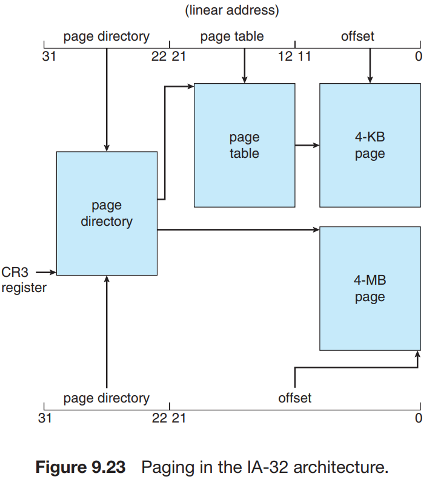

**Translation Process for 4KB Pages:**

1. **CR3 Register:** Contains the **physical address** of the **Page Directory** for the current process (loaded by the OS on a context switch).
2. **First Level - Page Directory:** Use the high 10 bits (`p1`) of the linear address as an index into the Page Directory. The entry found is a **Page Directory Entry (PDE)**.
3. **Second Level - Page Table:** The PDE contains the **physical address** of a **Page Table**. Use the next 10 bits (`p2`) as an index into this Page Table. The entry found is a **Page Table Entry (PTE)**.
4. **Frame & Offset:** The PTE contains the **physical frame number**. Combine this with the low 12-bit offset (`d`) to form the final physical address.

##### **2. 4 MB Large Pages (A Optimization)**

To reduce TLB pressure and page table depth for large, contiguous regions, IA-32 supports **4 MB pages**.

##### **3. Swapping Page Tables to Disk**

The page tables themselves can be large. To save physical memory, IA-32 allows **page tables (and even the page directory)** to be paged out to disk.

- **Invalid Bit:** The `present` bit in a PDE or PTE indicates if the referenced page table or page is **in memory** (`present=1`) or **on disk** (`present=0`).
- **OS Use of Entry:** If `present=0`, the remaining 31 bits of the entry are **not used by hardware**. The **operating system is free to use them** to store the **disk location** of the swapped-out page table. This is a classic example of hardware/software cooperation.

##### **4. Overcoming 32-bit Limits: Page Address Extension (PAE)**

The 32-bit address bus limited physical memory to 4 GB. To support more RAM (e.g., in servers), Intel introduced **PAE (Page Address Extension)**.

- **What it does:** Increases the **physical address space from 32 to 36 bits**, supporting up to **64 GB** of RAM. The **linear address remains 32 bits** (processes still have a 4 GB virtual address space).
- **Architectural Change:** Paging changes from **two-level to three-level**.
- **New Structure:** **Page Directory Pointer Table (PDPT)** → **Page Directory** → **Page Table** → **Page**.
- **Entry Size:** PDEs and PTEs expand from 32 to **64 bits** to hold the larger 24-bit base addresses (instead of 20-bit) needed for 36-bit physical addressing.
- **Visual Reference: Go to Figure 9.24.** This illustrates the three-level PAE scheme with 4KB pages. The CR3 register now points to a **PDPT**.

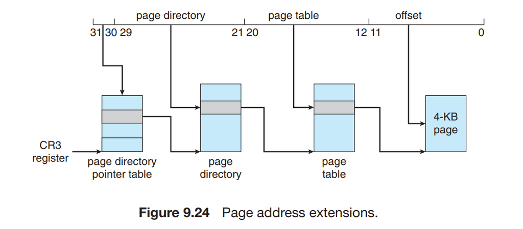

**Linear Address Split for PAE with 4KB Pages:**

```
| PDPT Index (2 bits) | Directory Index (9 bits) | Table Index (9 bits) | Offset (12 bits) |
```

(Note: Sizes shift due to 64-bit entries and alignment).

- **OS Support Required:** The operating system must be explicitly written to use PAE. **Linux** and **macOS** support it. However, **32-bit desktop Windows** versions typically artificially limit usable RAM to 4 GB for driver compatibility reasons, even if PAE is enabled in the CPU.

### **Section 9.6.2: x86-64 Architecture**

#### **1. Historical Context: AMD Leads the Way**

Intel's path to 64-bit computing was not straightforward.

- **Intel's First Attempt (IA-64/Itanium):** A completely new, non-x86 architecture. It failed to gain widespread adoption.
- **AMD's Innovation (x86-64):** AMD designed a **64-bit extension of the existing IA-32 (x86) instruction set**. This ensured **backward compatibility** with the vast library of existing 32-bit software, which was key to its success.
- **Role Reversal:** Intel, seeing AMD's success, ultimately **adopted AMD's x86-64 architecture** (marketing it as Intel 64, EM64T). This is the foundation of all modern 64-bit Intel and AMD PC/server processors.

#### **2. The 64-bit Address Space: Theory vs. Practice**

- **Theoretical Maximum:** A full 64-bit address space is **2^64 bytes = 16 Exabytes**. This is astronomically large.
- **Practical Implementation:** Current x86-64 CPUs **do not implement all 64 bits** in hardware. It would make address translation tables (page tables) impossibly large and complex.
- **Actual Virtual Address Size:** **48 bits**. This provides a **virtual address space of 256 Terabytes (2^48 bytes)** per process, which is still massive.
- **Canonical Address Form:** The upper 16 bits (bits 48-63) of a 64-bit virtual address must be a **sign extension** of bit 47 (all 0s or all 1s). This is a hardware requirement to allow future expansion to more bits while maintaining compatibility. This is why **Figure 9.25** shows bits 48-63 as "unused" in the current design.

#### **3. Paging Hierarchy: Four-Level Paging**

To manage the 48-bit virtual address space efficiently, x86-64 uses a **four-level hierarchical page table**. This is a direct extension of the two/three-level schemes seen in IA-32.

**Linear Address Split (48-bit effective, 64-bit format):** As shown in **Figure 9.25**, the bits are divided among the four levels and the offset. For a standard **4 KB page**:

- **Bits 47-39 (9 bits):** Index into the **Page Map Level 4 (PML4)** table.
- **Bits 38-30 (9 bits):** Index into the **Page Directory Pointer Table (PDPT)**.
- **Bits 29-21 (9 bits):** Index into the **Page Directory**.
- **Bits 20-12 (9 bits):** Index into the **Page Table**.
- **Bits 11-0 (12 bits):** Byte **Offset** within the 4 KB page.

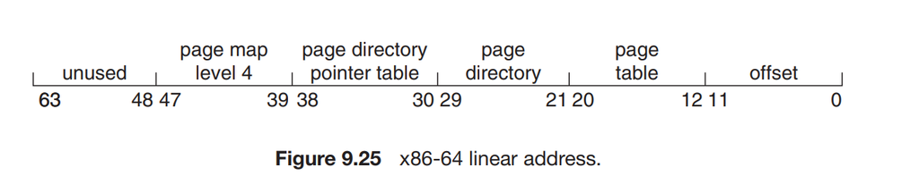

**Translation Walk:** The **CR3** register points to the physical base of the **PML4 table**. The MMU walks through each level using the indices, finally retrieving the physical frame number from the PTE.

#### **4. Page Sizes and Physical Address Support**

- **Supported Page Sizes:** **4 KB**, **2 MB**, and **1 GB**. Larger pages reduce TLB misses for big, contiguous memory regions.
- **Physical Address Space:** With **PAE technology extended**, x86-64 supports **52-bit physical addresses** (2^52 bytes = **4 Petabytes** of RAM). This is far beyond what current systems have, providing ample headroom. The physical frame numbers in PTEs are 52 bits wide.

**In summary, x86-64 is a 64-bit evolution of IA-32 that uses a 48-bit virtual address with a four-level page table hierarchy. It maintains backward compatibility while providing an enormous virtual and physical address space, using sophisticated paging with multiple page sizes to manage it efficiently.**

## **Chapter 9.7: Example: ARMv8 Architecture**

#### **1. Introduction: The Mobile and Embedded Giant**

While Intel dominates PCs/servers, **ARM** dominates the **mobile and embedded** world (smartphones, tablets, IoT). Its business model is unique: ARM **designs** the CPU architecture and **licenses** the designs to other companies (like Apple, Qualcomm, Samsung) who manufacture the chips.

- **Ubiquity:** Over **100 billion** ARM processors produced, making it the most produced CPU architecture ever.
- **Focus:** We examine the **64-bit ARMv8** architecture (used in modern smartphones and servers).

#### **2. Flexibility: Translation Granules**

A key design feature of ARMv8 is its **flexibility in the fundamental unit of translation**, called the **Translation Granule**. The OS can choose one of three sizes:

| Translation Granule | Page Size(s) | Region Size(s) |
| --- | --- | --- |
| **4 KB** | 4 KB | 2 MB, 1 GB |
| **16 KB** | 16 KB | 32 MB |
| **64 KB** | 64 KB | 512 MB |

- **Granule Size:** Defines the size of the **smallest unit** (page) and influences the structure of the page tables.
- **Region Sizes:** These are **large contiguous blocks** of memory that can be mapped by a **single entry** in an upper-level page table, bypassing deeper levels. This is a major optimization for mapping big chunks of memory (like the kernel or a large library) efficiently.

#### **3. Address Translation for 4 KB Granule (The Common Case)**

**Go to Figure 9.26.** This shows the **48-bit virtual address** split for the **4 KB translation granule** (note the unused high 16 bits, similar to x86-64). The address is divided into indices for up to **four levels** of page tables.

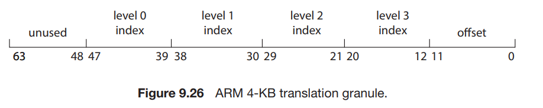

- **Bits 47-39 (9 bits):** Level 0 Index
- **Bits 38-30 (9 bits):** Level 1 Index
- **Bits 29-21 (9 bits):** Level 2 Index
- **Bits 20-12 (9 bits):** Level 3 Index
- **Bits 11-0 (12 bits):** Offset within a **4 KB Page**.

**Go to Figure 9.27.** This illustrates the **four-level hierarchical paging structure**. The **Translation Table Base Register (TTBR)** points to the Level 0 table for the current thread/process.

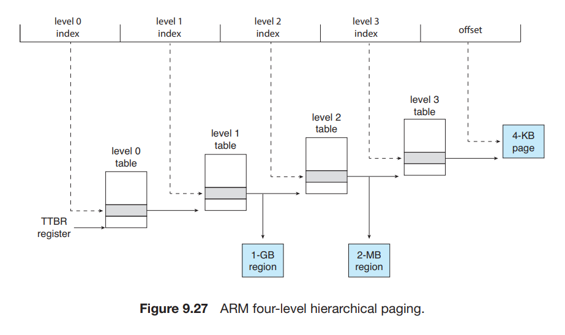

#### **4. The Power of Regions: Flexible Hierarchical Mapping**

This is where ARMv8 gets clever. Entries in the **Level 1** and **Level 2** tables are not *required* to point to a next-level table. They can instead point directly to a **Region**.

- **Level 1 Entry → 1 GB Region:** If a Level 1 entry is configured as a **region descriptor**, it maps a **contiguous 1 GB block** of virtual memory directly to physical memory. The translation stops here. The **low 30 bits** of the virtual address become the offset within this 1 GB region.
- **Level 2 Entry → 2 MB Region:** Similarly, a Level 2 entry can be a region descriptor for a **2 MB block**. The **low 21 bits** become the offset.
- **Benefit:** This drastically **reduces page table size and TLB usage** for large, contiguous memory areas. The OS kernel or a large app can be mapped with a handful of region entries instead of thousands of page entries.

#### **5. TLB Hierarchy: Micro TLBs and Main TLB**

ARMv8 uses a **two-level TLB hierarchy** for speed:

1. **Inner Level: Micro TLBs (µTLB):**
   - Very small, extremely fast TLBs that are **split** into a separate **Instruction µTLB** and **Data µTLB**.
   - They support **ASIDs** for process-specific tags.
   - The **first lookup** happens here, in parallel for instruction fetch and data access.
2. **Outer Level: Main TLB:**
   - A larger, unified TLB.
   - On a µTLB miss, the hardware checks the Main TLB.
3. **Page Table Walk:**
   - If both TLBs miss, the **hardware MMU performs an automatic page table walk** in memory (using the TTBR and the multi-level structure).
   - The resulting translation is loaded into the TLBs.

#### **6. Looking Ahead: The Need for 64-bit**

The sidebar on **64-bit Computing** poses a philosophical question: Will we ever need the full 64-bit address space (16 exabytes)?

**Consider future demands:**

- **In-memory Databases:** Entire corporate or even national datasets kept in RAM.
- **Advanced Simulation & AI:** Modeling complex systems (climate, proteins, the brain) at high fidelity requires massive memory.
- **Extreme Multimedia:** Ubiquitous high-fidelity 3D, holographic, or volumetric video.
- **Memory-centric Computing:** Architectures where memory is the central resource, not the CPU.

**History suggests** that software and data expand to consume available resources. While 48 bits (256 TB) is vast today, the jump to 64 bits provides an essentially **limitless headroom** for future, unimaginable applications, ensuring the architecture's longevity.

## **Section 9.8: Summary**

#### **1. The Central Role of Memory**

Memory (RAM) is the central storage that the CPU directly accesses to fetch instructions and data. It is organized as an array of addressable bytes.

#### **2. Basic Hardware Protection: Base and Limit Registers**

A fundamental hardware mechanism for memory protection and relocation uses two registers:

- **Base Register:** Holds the starting physical address of a process.
- **Limit Register:** Holds the size of the process's address space. Together, they define a protected, contiguous memory region. Every address is checked against the limit and added to the base by the MMU.

#### **3. Address Binding Timing**

The mapping of symbolic addresses to physical addresses can occur at different times, affecting flexibility:

- **Compile Time:** Generates absolute code. Inflexible.
- **Load Time:** Generates relocatable code. Binding occurs on load.
- **Execution Time:** Binding delayed until runtime. Requires hardware (MMU) support. Used by all modern systems.

#### **4. Logical vs. Physical Addresses**

- **Logical (Virtual) Address:** Generated by the CPU. The process's view of memory.
- **Physical Address:** The actual address on the memory bus. The **Memory Management Unit (MMU)** translates logical addresses to physical addresses.

#### **5. Contiguous Memory Allocation & Its Problems**

Early systems allocated **contiguous partitions** to processes. Placement strategies included:

- **First-Fit:** Fast, allocates the first suitable hole.
- **Best-Fit:** Minimizes leftover hole size, but creates many tiny fragments.
- **Worst-Fit:** Maximizes leftover hole, generally performs poorly. All suffer from **external fragmentation** (free memory broken into small, non-contiguous holes) and may require **compaction**.

#### **6. Paging: The Fundamental Solution**

Paging eliminates external fragmentation by allowing a process's physical memory to be **noncontiguous**.

- Physical memory divided into **frames**.
- Logical memory divided into **pages** of the same size.
- The **page table** (one per process) maps **page numbers** to **frame numbers**.
- The logical address is split: `(Page Number p, Page Offset d)`.
- The page number indexes the page table; the retrieved frame number is combined with the offset to form the physical address.

#### **7. The Translation Lookaside Buffer (TLB)**

A hardware cache for page table entries to avoid the performance penalty of a memory access for every translation.

- **TLB Hit:** Translation is immediate (fast path).
- **TLB Miss:** Requires a full page table walk (slow). The new mapping is then loaded into the TLB.
- **Address-Space Identifiers (ASIDs)** allow the TLB to hold entries for multiple processes without flushing on a context switch.

#### **8. Structuring Page Tables for Large Address Spaces**

Simple linear page tables are too large for 32/64-bit spaces. Solutions include:

- **Hierarchical (Multi-Level) Paging:** The page table itself is paged. Standard for 32-bit (2 levels) and 64-bit (3-4 levels) systems.
- **Hashed Page Tables:** Uses a hash table to map virtual page numbers to entries. Good for sparse address spaces.
- **Inverted Page Tables:** One system-wide table indexed by physical frame number. Saves space but complicates sharing and requires hashing for performance.

#### **9. Swapping**

The technique of moving process data between memory and backing store (disk) to allow **memory oversubscription**.

- **Standard Swapping:** Moves entire processes. Too slow, rarely used.
- **Swapping with Paging (Modern):** Moves individual pages. The core mechanism of **virtual memory**.
- **Mobile Systems:** Typically do **not** swap due to flash memory wear and performance constraints. They use app termination and state preservation instead.

#### **10. Real-World Architectures**

- **Intel IA-32 (32-bit):** Uses combined **segmentation** (often neutralized) and **paging** (two-level, with PAE for >4GB RAM).
- **Intel/AMD x86-64 (64-bit):** Uses **48-bit virtual addresses** with a **four-level page table hierarchy**. Supports 4 KB, 2 MB, and 1 GB pages.
- **ARMv8 (64-bit):** Highly flexible with **translation granules** (4 KB, 16 KB, 64 KB) and **region mappings**. Uses a **two-level TLB** (micro TLBs and main TLB) and up to four levels of paging.

#### **Key Takeaway**

Modern memory management is built on **paging**, which provides the illusion of a large, private, contiguous address space for each process while efficiently using and protecting physical memory through hardware-assisted translation (MMU, TLB) and sophisticated OS data structures (page tables). This foundation enables **virtual memory**, explored in the next chapter.